# Project 2 DS6306

Todd Garner

2023-04-01

https://github.com/SMU-DataHub/CaseStudy2DDS/blob/main/Presentation_Frito_Lay.mp4

Link to my video

# Welsome Frito Lay - Attrition, trends, Monthly income predictor among other important tasks.

##Pinnacle Economics, LLC would like to thank Frito Lay for hiring our company to do this important work for you. We are honored and excited about performing these tasks. The first thing I want to say is that the data set CaseStudy2-data.csv required some preparation prior to thorough analysis. I used Excel to load the data set into RStudio by parsing the comma separated values into individual columns. My work is shown and commented below.

```r
#Load CaseStudy2-data_excel.xlsx from the main directory in the GitHub repo.
CS2 = readxl::read_excel(file.choose())
#View(CS2)
```

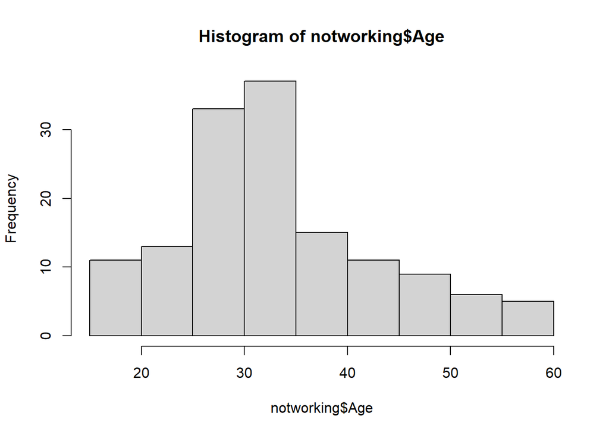

```r
working <- CS2 %>% filter(Attrition == "No")
working <- CS2 %>% filter(Attrition == "No")
notworking <- CS2 %>% filter(Attrition == "Yes")
tenure1 <- max(CS2$YearsAtCompany)

#In order to perform a proper EDA, it's necessary to evaluate the "not working" elements of the full data set.  I've created numerous histograms in order to do just that.  These can all be found in the "images" folder in the GitHub repo.

hist(notworking$Age)
hist(notworking$Age)
```

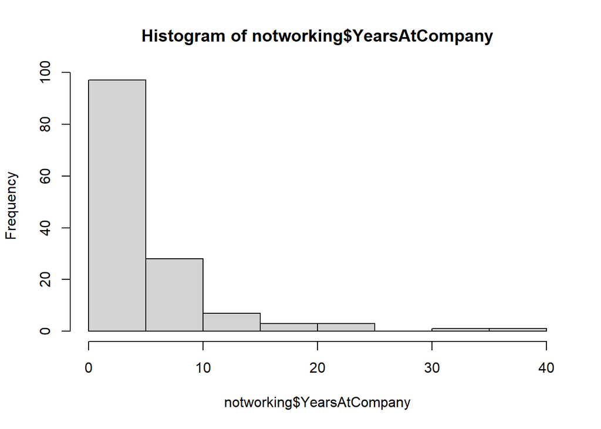

```r
hist(notworking$YearsAtCompany)
```

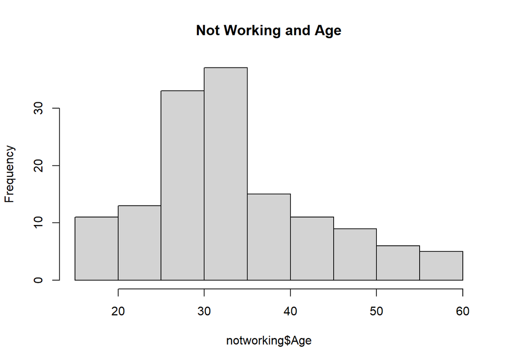

```r
hist(notworking$Age, main = "Not Working and Age")
```

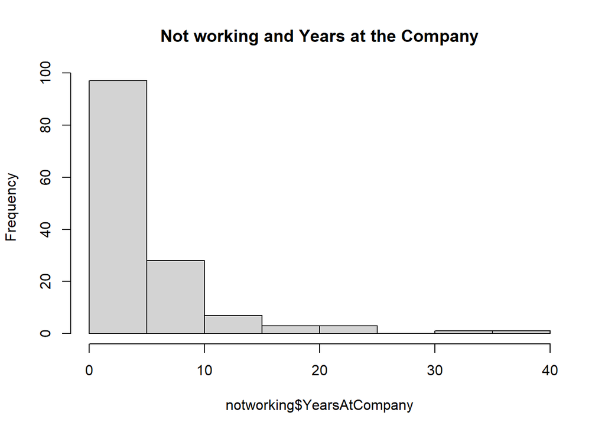

```r
hist(notworking$YearsAtCompany, main = "Not working and Years at the Company")
```

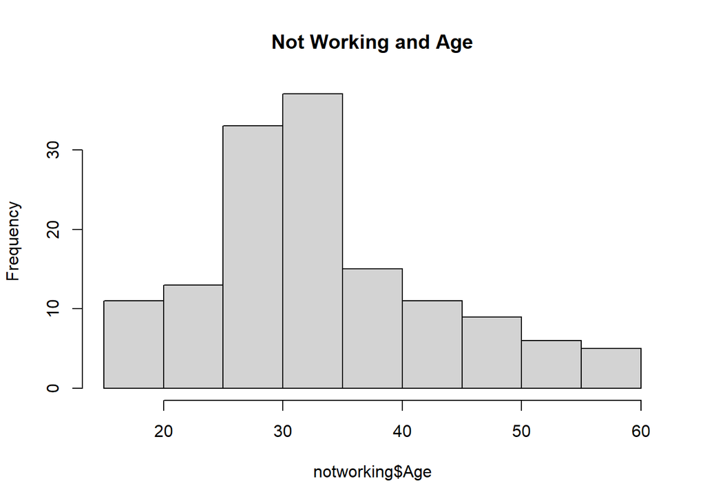

```r
hist(notworking$Age, main = "Not Working and Age")
```

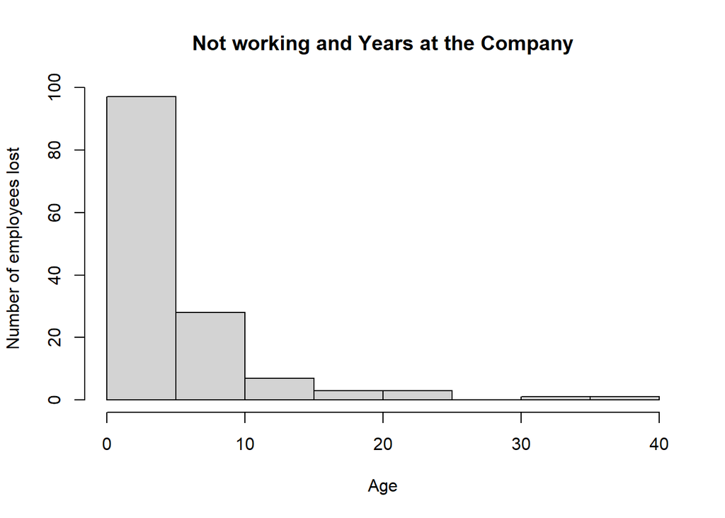

```r
hist(notworking$YearsAtCompany, main = "Not working and Years at the Company", xlab = "Age", ylab = "Number of employees lost")
```

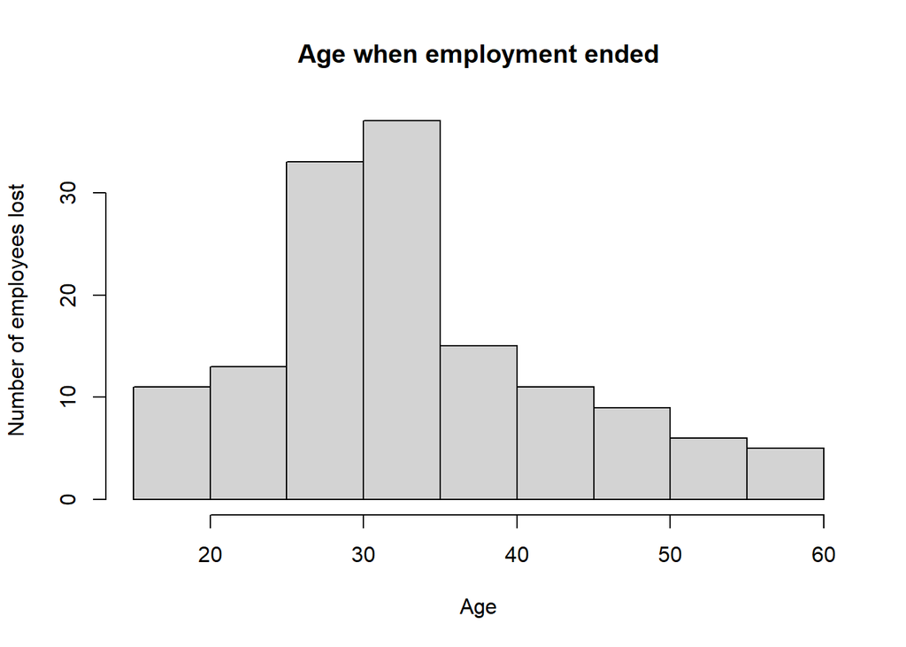

```r
hist(notworking$Age, main = "Age when employment ended", xlab = "Age", ylab = "Number of employees lost")
```

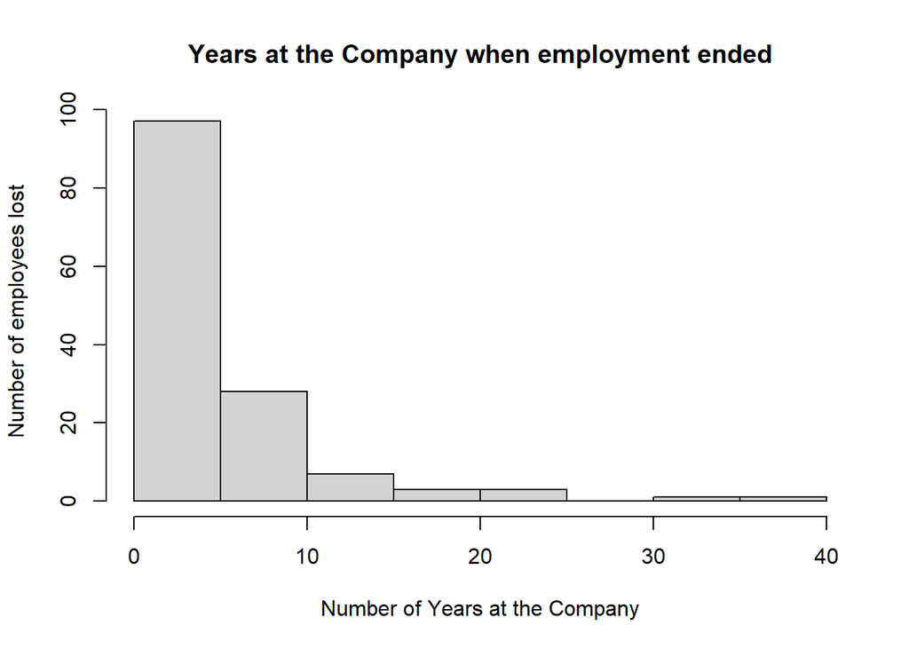

```r
hist(notworking$YearsAtCompany, main = "Years at the Company when employment ended", xlab = "Number of Years at the Company", ylab = "Number of employees lost")
```

```r
summary(notworking$Age)
```

```
##    Min. 1st Qu.  Median    Mean 3rd Qu.    Max.
##   18.00   28.00   32.00   33.79   39.00   58.00
```

```r
summary(notworking$YearsAtCompany)
```

```
##    Min. 1st Qu.  Median    Mean 3rd Qu.    Max.
##   0.000   1.000   3.000   5.193   8.000  40.000
```

```r
t.test(notworking$Age)
```

```
##
##  One Sample t-test
##
## data:  notworking$Age
## t = 41.578, df = 139, p-value < 2.2e-16
## alternative hypothesis: true mean is not equal to 0
## 95 percent confidence interval:
##  32.17907 35.39235
## sample estimates:
## mean of x
##  33.78571
```

```r
t.test(notworking$YearsAtCompany)
```

```
##
##  One Sample t-test
##
## data:  notworking$YearsAtCompany
## t = 9.9562, df = 139, p-value < 2.2e-16
## alternative hypothesis: true mean is not equal to 0
## 95 percent confidence interval:
##  4.161622 6.224092
## sample estimates:
## mean of x
##  5.192857
```

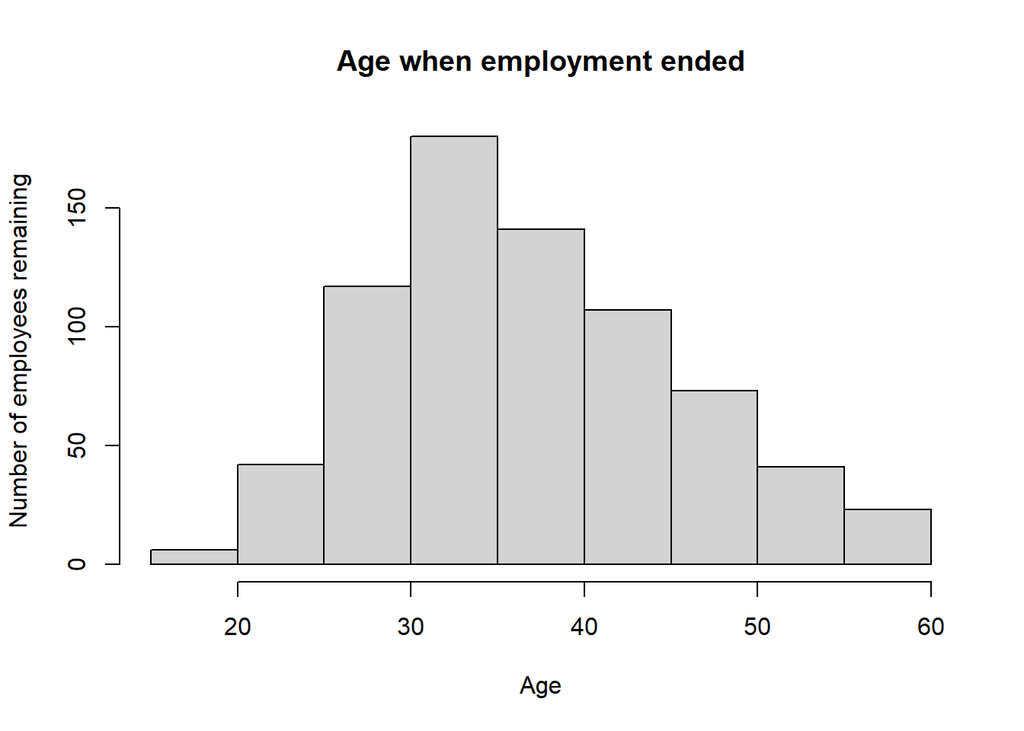

```r
hist(working$Age, main = "Age when employment ended", xlab = "Age", ylab = "Number of employees remaining")
```

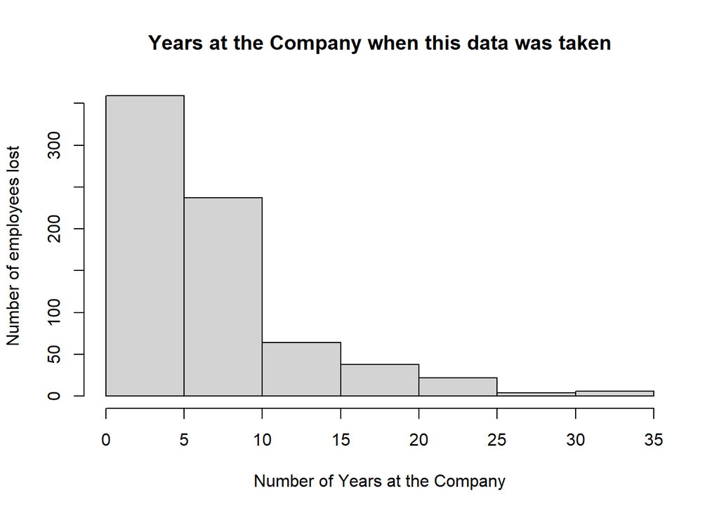

```r
hist(working$YearsAtCompany, main = "Years at the Company when this data was taken", xlab = "Number of Years at the Company", ylab = "Number of employees lost")
```

```r
summary(working$Age)
```

```
##    Min. 1st Qu.  Median    Mean 3rd Qu.    Max.
##   18.00   31.00   36.00   37.41   43.00   60.00
```

```r
summary(working$YearsAtCompany)
```

```
##    Min. 1st Qu.  Median    Mean 3rd Qu.    Max.
##   0.000   3.000   6.000   7.301  10.000  33.000
```

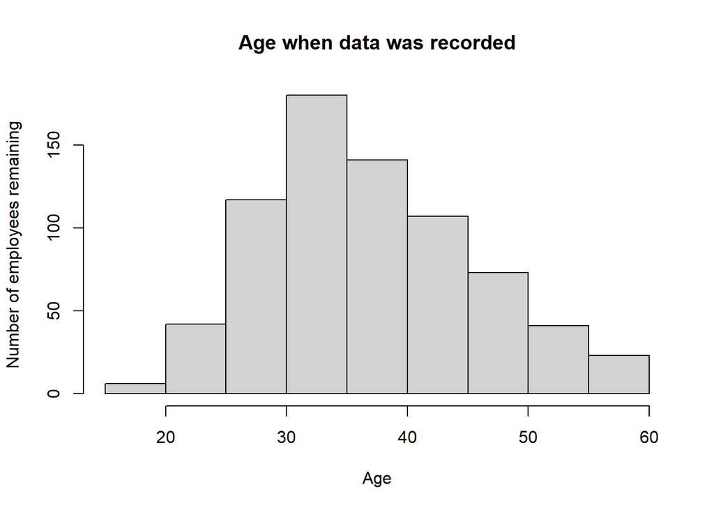

```r
hist(working$Age, main = "Age when data was recorded", xlab = "Age", ylab = "Number of employees remaining")
```

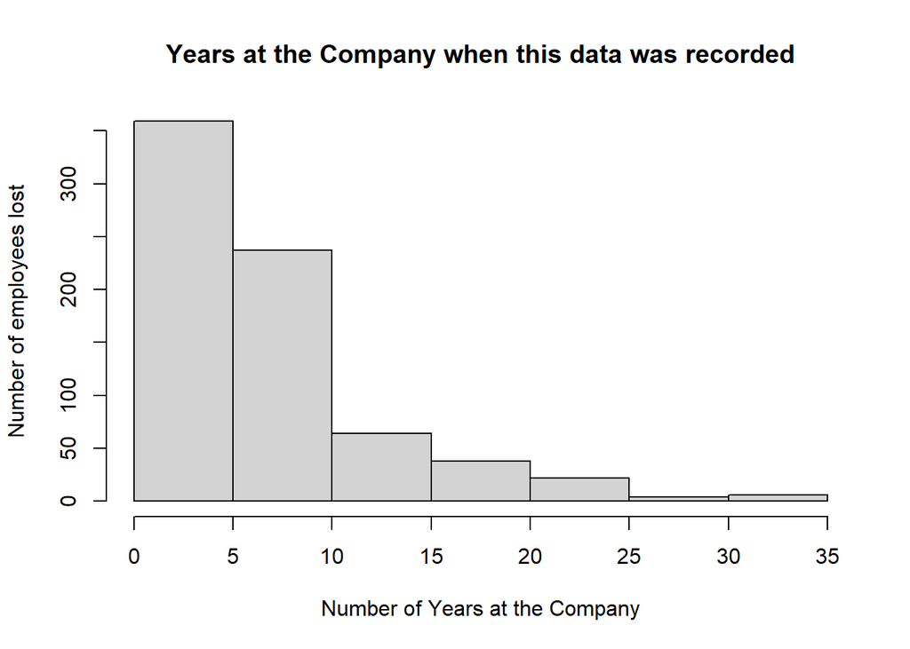

```r
hist(working$YearsAtCompany, main = "Years at the Company when this data was recorded", xlab = "Number of Years at the Company", ylab = "Number of employees lost")
```

```r
summary(working$Age)
```

```
##    Min. 1st Qu.  Median    Mean 3rd Qu.    Max.
##   18.00   31.00   36.00   37.41   43.00   60.00
```

```r
summary(working$YearsAtCompany)
```

```
##    Min. 1st Qu.  Median    Mean 3rd Qu.    Max.
##   0.000   3.000   6.000   7.301  10.000  33.000
```

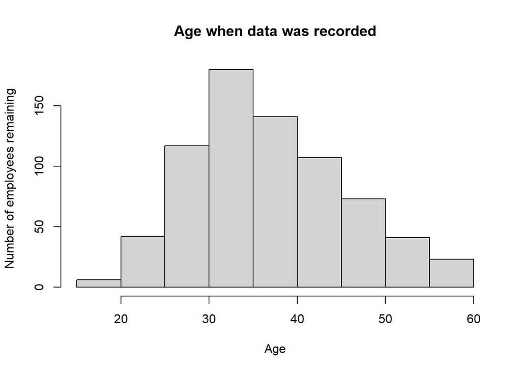

```r
hist(working$Age, main = "Age when data was recorded", xlab = "Age", ylab = "Number of employees remaining")
```

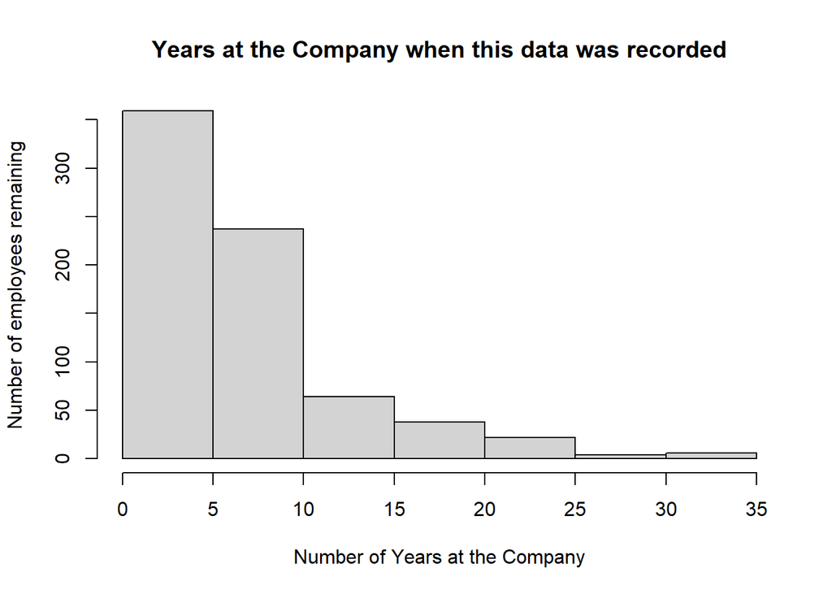

```r
hist(working$YearsAtCompany, main = "Years at the Company when this data was recorded", xlab = "Number of Years at the Company", ylab = "Number of employees remaining")
```

```r
summary(working$Age)
```

```
##    Min. 1st Qu.  Median    Mean 3rd Qu.    Max.
##   18.00   31.00   36.00   37.41   43.00   60.00
```

```r
summary(working$YearsAtCompany)
```

```
##    Min. 1st Qu.  Median    Mean 3rd Qu.    Max.
##   0.000   3.000   6.000   7.301  10.000  33.000
```

```r
t.test(working$Age)
```

```
##
##  One Sample t-test
##
## data:  working$Age
## t = 116.54, df = 729, p-value < 2.2e-16
## alternative hypothesis: true mean is not equal to 0
## 95 percent confidence interval:
##  36.78210 38.04256
## sample estimates:
## mean of x
##  37.41233
```

```r
t.test(working$YearsAtCompany)
```

```
##
##  One Sample t-test
##
## data:  working$YearsAtCompany
## t = 33.233, df = 729, p-value < 2.2e-16
## alternative hypothesis: true mean is not equal to 0
## 95 percent confidence interval:
##  6.870042 7.732697
## sample estimates:
## mean of x
##   7.30137
```

We have three useful data sets. CS2 - all data, working - those employees still working at Frito Lay, notworking - those employees that have left the company. Notworking could include fired, resigned, died, retired. I can’t think of any other reasons, but I don’t think that’s relevant.

I plotted all of the histograms and got the summary() for the notworking data set with with each variable on the X axis and the count on the Y axis. Those were saved as PDF’s. A few were notable but we need more data analysis.

```r
KNN_ALL <- CS2
#View(KNN_ALL)
```

Now we have a new data.frame with all 870 observations. Perhaps we should deal with missing values. Amazingly, there appear to be no missing values. So, there are a few columns that have binary values. We can change those to 0 and 1. All employees are/were over 18. That column adds no value so we should drop it as well as EmployeeCount. There are 5 columns with multiple characters in categories. For now, I’m going to drop those columns out of the data.frame. We will return and convert these to factors which assigns a “dummy” variable in the data set in place of the different levels in each variable/factor.

```r
#summary(KNN_ALL)
sum(is.na(KNN_ALL))
```

```
## [1] 0
```

```r
#convert binary columns to 1s and 0s.
KNN_ALL$Attrition <- str_replace(KNN_ALL$Attrition,"No", "1")
KNN_ALL$Attrition <- str_replace(KNN_ALL$Attrition,"Yes", "0")
#KNN_ALL$Attrition
KNN_ALL$Gender <- str_replace(KNN_ALL$Gender,"Female", "1")
KNN_ALL$Gender <- str_replace(KNN_ALL$Gender,"Male", "0")
#KNN_ALL$Gender
KNN_ALL$OverTime <- str_replace(KNN_ALL$OverTime,"Yes", "1")
KNN_ALL$OverTime <- str_replace(KNN_ALL$OverTime,"No", "0")
#KNN_ALL$OverTime
KNN_ALL$OverTime <- str_replace(KNN_ALL$OverTime,"Yes", "1")
KNN_ALL$OverTime <- str_replace(KNN_ALL$OverTime,"No", "0")
#KNN_ALL$OverTime

#Remove the BusinessTravel, Department, EducationField, JobRole, MaritalStatus columns. These are the columns that have multiple levels.
KNN_ALL[ , c('BusinessTravel', 'Department', 'EducationField', 'JobRole', 'MaritalStatus')] <- list(NULL)
#View(KNN_ALL)
KNN_ALL[ , c('Over18')] <- list(NULL)
#View(KNN_ALL)
#summary(KNN_ALL)
```

We need to convert all character columns to numeric

```r
KNN_ALL$Attrition <- as.numeric(KNN_ALL$Attrition)
KNN_ALL$Gender <- as.numeric(KNN_ALL$Gender)
KNN_ALL$OverTime <- as.numeric(KNN_ALL$OverTime)
#summary(KNN_ALL)
str(KNN_ALL)
```

```
## tibble [870 × 30] (S3: tbl_df/tbl/data.frame)
##  $ ID                      : num [1:870] 1 2 3 4 5 6 7 8 9 10 ...
##  $ Age                     : num [1:870] 32 40 35 32 24 27 41 37 34 34 ...
##  $ Attrition               : num [1:870] 1 1 1 1 1 1 1 1 1 1 ...
##  $ DailyRate               : num [1:870] 117 1308 200 801 567 ...
##  $ DistanceFromHome        : num [1:870] 13 14 18 1 2 10 5 10 10 10 ...
##  $ Education               : num [1:870] 4 3 2 4 1 2 5 4 4 4 ...
##  $ EmployeeCount           : num [1:870] 1 1 1 1 1 1 1 1 1 1 ...
##  $ EmployeeNumber          : num [1:870] 859 1128 1412 2016 1646 ...
##  $ EnvironmentSatisfaction : num [1:870] 2 3 3 3 1 4 2 4 3 4 ...
##  $ Gender                  : num [1:870] 0 0 0 1 1 0 0 1 1 0 ...
##  $ HourlyRate              : num [1:870] 73 44 60 48 32 32 90 88 87 92 ...
##  $ JobInvolvement          : num [1:870] 3 2 3 3 3 3 4 2 3 2 ...
##  $ JobLevel                : num [1:870] 2 5 3 3 1 3 1 2 1 2 ...
##  $ JobSatisfaction         : num [1:870] 4 3 4 4 4 1 3 4 3 3 ...
```

[output cut: 16 more lines]

All columns are numeric. Now, we need to scale all columns. But, first remove the binary columns. Scaling those doesn’t make sense. We’ll add those back shortly.

```r
KNN_ALL[ , c('Attrition', 'EmployeeCount', 'Gender', 'OverTime')] <- list(NULL)
#View(KNN_ALL)

KNN_ALL_standardize <- as.data.frame(scale(KNN_ALL)) #, KNN_ALL[4:6], KNN_ALL[8:9], KNN_ALL[11:17], KNN_ALL[19:30]))
#View(KNN_ALL_standardize)
```

We want to add back several of the binary columns to the KNN_ALL_standardized data.frame. Attrition, EmployeeCount, Gender and OverTime

```r
KNN_ALL_standardize <- cbind(CS2$Attrition, CS2$EmployeeCount, CS2$Gender, CS2$OverTime, KNN_ALL_standardize)
#View(KNN_ALL_standardize)

colnames(KNN_ALL_standardize)[colnames(KNN_ALL_standardize) == 'CS2$OverTime'] <- 'OverTime'
colnames(KNN_ALL_standardize)[colnames(KNN_ALL_standardize) == 'CS2$Gender'] <- 'Gender'
colnames(KNN_ALL_standardize)[colnames(KNN_ALL_standardize) == 'CS2$EmployeeCount'] <- 'EmployeeCount'
colnames(KNN_ALL_standardize)[colnames(KNN_ALL_standardize) == 'CS2$Attrition'] <- 'Attrition'

KNN_ALL_standardize$Attrition <- str_replace(KNN_ALL_standardize$Attrition,"No", "1")
KNN_ALL_standardize$Attrition <- str_replace(KNN_ALL_standardize$Attrition,"Yes", "0")
#KNN_ALL_standardize$Attrition
KNN_ALL_standardize$Gender <- str_replace(KNN_ALL_standardize$Gender,"Female", "1")
KNN_ALL_standardize$Gender <- str_replace(KNN_ALL_standardize$Gender,"Male", "0")
#KNN_ALL_standardize$Gender
KNN_ALL_standardize$OverTime <- str_replace(KNN_ALL_standardize$OverTime,"Yes", "1")
KNN_ALL_standardize$OverTime <- str_replace(KNN_ALL_standardize$OverTime,"No", "0")
#KNN_ALL_standardize$OverTime
KNN_ALL_standardize$OverTime <- str_replace(KNN_ALL_standardize$OverTime,"Yes", "1")
KNN_ALL_standardize$OverTime <- str_replace(KNN_ALL_standardize$OverTime,"No", "0")
#KNN_ALL_standardize$OverTime

colnames(KNN_ALL_standardize)[colnames(KNN_ALL_standardize) == 'CS2$OverTime'] <- 'OverTime'
colnames(KNN_ALL_standardize)[colnames(KNN_ALL_standardize) == 'CS2$Gender'] <- 'Gender'
colnames(KNN_ALL_standardize)[colnames(KNN_ALL_standardize) == 'CS2$EmployeeCount'] <- 'EmployeeCount'
colnames(KNN_ALL_standardize)[colnames(KNN_ALL_standardize) == 'CS2$Attrition'] <- 'Attrition'

#head(KNN_ALL_standardize)
str(KNN_ALL_standardize)
```

```
## 'data.frame':    870 obs. of  30 variables:
##  $ Attrition               : chr  "1" "1" "1" "1" ...
##  $ EmployeeCount           : num  1 1 1 1 1 1 1 1 1 1 ...
##  $ Gender                  : chr  "0" "0" "0" "1" ...
##  $ OverTime                : chr  "0" "0" "0" "0" ...
##  $ ID                      : num  -1.73 -1.73 -1.72 -1.72 -1.71 ...
##  $ Age                     : num  -0.541 0.355 -0.205 -0.541 -1.437 ...
##  $ DailyRate               : num  -1.7407 1.2285 -1.5338 -0.0355 -0.6188 ...
##  $ DistanceFromHome        : num  0.45 0.573 1.064 -1.025 -0.902 ...
##  $ Education               : num  1.0741 0.0966 -0.8809 1.0741 -1.8583 ...
##  $ EmployeeNumber          : num  -0.282 0.162 0.632 1.631 1.019 ...
##  $ EnvironmentSatisfaction : num  -0.638 0.272 0.272 0.272 -1.547 ...
##  $ HourlyRate              : num  0.367 -1.074 -0.279 -0.875 -1.67 ...
##  $ JobInvolvement          : num  0.394 -1.028 0.394 0.394 0.394 ...
##  $ JobLevel                : num  -0.0358 2.7162 0.8815 0.8815 -0.9532 ...
```

[output cut: 16 more lines]

I had to rename the first four columns to the appropriate names and then change them to numeric. Attrition, Gender OverTime.

```r
KNN_ALL_standardize$Attrition <- as.numeric(KNN_ALL_standardize$Attrition)
KNN_ALL_standardize$Gender <- as.numeric(KNN_ALL_standardize$Gender)
KNN_ALL_standardize$OverTime <- as.numeric(KNN_ALL_standardize$OverTime)
#summary(KNN_ALL_standardize)
str(KNN_ALL_standardize)
```

```
## 'data.frame':    870 obs. of  30 variables:
##  $ Attrition               : num  1 1 1 1 1 1 1 1 1 1 ...
##  $ EmployeeCount           : num  1 1 1 1 1 1 1 1 1 1 ...
##  $ Gender                  : num  0 0 0 1 1 0 0 1 1 0 ...
##  $ OverTime                : num  0 0 0 0 1 0 1 1 1 0 ...
##  $ ID                      : num  -1.73 -1.73 -1.72 -1.72 -1.71 ...
##  $ Age                     : num  -0.541 0.355 -0.205 -0.541 -1.437 ...
##  $ DailyRate               : num  -1.7407 1.2285 -1.5338 -0.0355 -0.6188 ...
##  $ DistanceFromHome        : num  0.45 0.573 1.064 -1.025 -0.902 ...
##  $ Education               : num  1.0741 0.0966 -0.8809 1.0741 -1.8583 ...
##  $ EmployeeNumber          : num  -0.282 0.162 0.632 1.631 1.019 ...
##  $ EnvironmentSatisfaction : num  -0.638 0.272 0.272 0.272 -1.547 ...
##  $ HourlyRate              : num  0.367 -1.074 -0.279 -0.875 -1.67 ...
##  $ JobInvolvement          : num  0.394 -1.028 0.394 0.394 0.394 ...
##  $ JobLevel                : num  -0.0358 2.7162 0.8815 0.8815 -0.9532 ...
```

[output cut: 16 more lines]

Now the KNN_ALL_standardize data.frame is ready for analysis. Thinking this through, there are many more data points in the Attrition = “No” category than “Yes”. Attrition = “No” means they are still employed at Frito Lay, or were when this data was gathered. Perhaps it’s best to split the dataset into a training and testing set to see if it remains as unbalanced.

```r
splitPerc = .75
Full_set = KNN_ALL_standardize %>% filter(Attrition == "1" | Attrition == "0")
trainInices = sample(1:dim(Full_set)[1],round(splitPerc * dim(Full_set)[1]))
train = Full_set[trainInices,]
test = Full_set[-trainInices,]
```

```r
summary(train)
```

```
##    Attrition      EmployeeCount     Gender          OverTime
##  Min.   :0.0000   Min.   :1     Min.   :0.0000   Min.   :0.0000
##  1st Qu.:1.0000   1st Qu.:1     1st Qu.:0.0000   1st Qu.:0.0000
##  Median :1.0000   Median :1     Median :0.0000   Median :0.0000
##  Mean   :0.8298   Mean   :1     Mean   :0.4034   Mean   :0.2945
##  3rd Qu.:1.0000   3rd Qu.:1     3rd Qu.:1.0000   3rd Qu.:1.0000
##  Max.   :1.0000   Max.   :1     Max.   :1.0000   Max.   :1.0000
##
##        ID                 Age             DailyRate         DistanceFromHome
##  Min.   :-1.729067   Min.   :-2.10944   Min.   :-1.775614   Min.   :-1.024872
##  1st Qu.:-0.890400   1st Qu.:-0.76504   1st Qu.:-0.873756   1st Qu.:-0.901972
##  Median :-0.007959   Median :-0.20488   Median :-0.015526   Median :-0.287473
##  Mean   :-0.012781   Mean   : 0.00252   Mean   :-0.005003   Mean   : 0.003378
##  3rd Qu.: 0.862544   3rd Qu.: 0.69138   3rd Qu.: 0.906900   3rd Qu.: 0.695726
##  Max.   : 1.725087   Max.   : 2.59594   Max.   : 1.704674   Max.   : 2.416325
##
##    Education        EmployeeNumber     EnvironmentSatisfaction
##  Min.   :-1.85834   Min.   :-1.70114   Min.   :-1.547376
##  1st Qu.:-0.88086   1st Qu.:-0.92070   1st Qu.:-0.637770
##  Median : 0.09662   Median : 0.03252   Median : 0.271836
##  Mean   : 0.02466   Mean   : 0.01047   Mean   :-0.001604
##  3rd Qu.: 1.07411   3rd Qu.: 0.92457   3rd Qu.: 1.181443
##  Max.   : 2.05159   Max.   : 1.70666   Max.   : 1.181443
##
##    HourlyRate        JobInvolvement        JobLevel        JobSatisfaction
##  Min.   :-1.769439   Min.   :-2.44871   Min.   :-0.95319   Min.   :-1.533575
##  1st Qu.:-0.875126   1st Qu.:-1.02751   1st Qu.:-0.95319   1st Qu.:-0.636325
##  Median : 0.019188   Median : 0.39369   Median :-0.03585   Median : 0.260924
##  Mean   : 0.001433   Mean   :-0.04444   Mean   :-0.02319   Mean   :-0.004673
##  3rd Qu.: 0.863818   3rd Qu.: 0.39369   3rd Qu.:-0.03585   3rd Qu.: 1.158174
##  Max.   : 1.708448   Max.   : 1.81489   Max.   : 2.71616   Max.   : 1.158174
##
##  MonthlyIncome       MonthlyRate        NumCompaniesWorked PercentSalaryHike
##  Min.   :-1.15477   Min.   :-1.720732   Min.   :-1.08219   Min.   :-1.14272
##  1st Qu.:-0.78485   1st Qu.:-0.867655   1st Qu.:-0.68543   1st Qu.:-0.87064
##  Median :-0.31891   Median :-0.042291   Median :-0.28867   Median :-0.32649
##  Mean   :-0.02294   Mean   :-0.006343   Mean   : 0.01985   Mean   :-0.02228
##  3rd Qu.: 0.27568   3rd Qu.: 0.849544   3rd Qu.: 0.50484   3rd Qu.: 0.76181
##  Max.   : 2.95990   Max.   : 1.782597   Max.   : 2.48862   Max.   : 2.66635
##
```

[output cut: 9 more lines]

```
##  Min.   :-1.47104   Min.   :-2.225396     Min.   :-2.50234   Min.   :-1.15629
##  1st Qu.:-0.67249   1st Qu.:-0.653891     1st Qu.:-1.09780   1st Qu.:-0.82412
##  Median :-0.14013   Median : 0.131862     Median : 0.30674   Median :-0.32587
##  Mean   :-0.02684   Mean   :-0.003114     Mean   :-0.02285   Mean   :-0.04159
##  3rd Qu.: 0.39224   3rd Qu.: 0.131862     3rd Qu.: 0.30674   3rd Qu.: 0.33847
##  Max.   : 3.85260   Max.   : 2.489120     Max.   : 1.71128   Max.   : 5.48708
##
##  YearsInCurrentRole YearsSinceLastPromotion YearsWithCurrManager
##  Min.   :-1.15533   Min.   :-0.68081        Min.   :-1.15829
##  1st Qu.:-0.60577   1st Qu.:-0.68081        1st Qu.:-0.59876
##  Median :-0.33100   Median :-0.36692        Median :-0.31899
##  Mean   :-0.03472   Mean   :-0.03137        Mean   :-0.03623
##  3rd Qu.: 0.76811   3rd Qu.:-0.05304        3rd Qu.: 0.80006
##  Max.   : 3.79066   Max.   : 4.02748        Max.   : 3.59770
##
```

```r
summary(test)
```

```
##    Attrition     EmployeeCount     Gender          OverTime
##  Min.   :0.000   Min.   :1     Min.   :0.0000   Min.   :0.0000
##  1st Qu.:1.000   1st Qu.:1     1st Qu.:0.0000   1st Qu.:0.0000
##  Median :1.000   Median :1     Median :0.0000   Median :0.0000
##  Mean   :0.867   Mean   :1     Mean   :0.4174   Mean   :0.2752
##  3rd Qu.:1.000   3rd Qu.:1     3rd Qu.:1.0000   3rd Qu.:1.0000
##  Max.   :1.000   Max.   :1     Max.   :1.0000   Max.   :1.0000
##
##        ID                Age              DailyRate        DistanceFromHome
##  Min.   :-1.71713   Min.   :-2.109438   Min.   :-1.75567   Min.   :-1.0249
##  1st Qu.:-0.74515   1st Qu.:-0.765043   1st Qu.:-0.78151   1st Qu.:-0.9020
##  Median : 0.01990   Median :-0.204878   Median : 0.11037   Median :-0.2875
##  Mean   : 0.03822   Mean   :-0.007536   Mean   : 0.01496   Mean   :-0.0101
##  3rd Qu.: 0.85657   3rd Qu.: 0.579352   3rd Qu.: 0.81466   3rd Qu.: 0.5728
##  Max.   : 1.72907   Max.   : 2.147812   Max.   : 1.69470   Max.   : 2.4163
##
##    Education        EmployeeNumber     EnvironmentSatisfaction
##  Min.   :-1.85834   Min.   :-1.68461   Min.   :-1.547376
##  1st Qu.:-0.88086   1st Qu.:-0.87275   1st Qu.:-0.637770
##  Median : 0.09662   Median :-0.03362   Median : 0.271836
##  Mean   :-0.07376   Mean   :-0.03131   Mean   : 0.004796
##  3rd Qu.: 1.07411   3rd Qu.: 0.83280   3rd Qu.: 1.181443
##  Max.   : 2.05159   Max.   : 1.70996   Max.   : 1.181443
##
##    HourlyRate        JobInvolvement       JobLevel        JobSatisfaction
##  Min.   :-1.769439   Min.   :-2.4487   Min.   :-0.95319   Min.   :-1.53358
##  1st Qu.:-0.875126   1st Qu.:-1.0275   1st Qu.:-0.95319   1st Qu.:-0.63633
##  Median : 0.019188   Median : 0.3937   Median :-0.03585   Median : 0.26092
##  Mean   :-0.004286   Mean   : 0.1329   Mean   : 0.06935   Mean   : 0.01397
##  3rd Qu.: 0.851397   3rd Qu.: 0.3937   3rd Qu.: 0.88149   3rd Qu.: 1.15817
##  Max.   : 1.708448   Max.   : 1.8149   Max.   : 2.71616   Max.   : 1.15817
##
##  MonthlyIncome      MonthlyRate       NumCompaniesWorked PercentSalaryHike
##  Min.   :-1.1526   Min.   :-1.71468   Min.   :-1.08219   Min.   :-1.14272
##  1st Qu.:-0.7275   1st Qu.:-0.86695   1st Qu.:-0.68543   1st Qu.:-0.87064
##  Median :-0.3108   Median :-0.01648   Median :-0.68543   Median :-0.32649
##  Mean   : 0.0686   Mean   : 0.01897   Mean   :-0.05936   Mean   : 0.06665
##  3rd Qu.: 0.6923   3rd Qu.: 0.96508   3rd Qu.: 0.50484   3rd Qu.: 0.76181
##  Max.   : 2.8810   Max.   : 1.77359   Max.   : 2.48862   Max.   : 2.66635
##
```

[output cut: 9 more lines]

```
##  Min.   :-1.47104   Min.   :-2.225396     Min.   :-2.50234   Min.   :-1.1563
##  1st Qu.:-0.67249   1st Qu.:-0.653891     1st Qu.: 0.30674   1st Qu.:-0.6580
##  Median :-0.14013   Median : 0.131862     Median : 0.30674   Median :-0.1598
##  Mean   : 0.08027   Mean   : 0.009313     Mean   : 0.06835   Mean   : 0.1244
##  3rd Qu.: 0.52533   3rd Qu.: 0.131862     3rd Qu.: 0.30674   3rd Qu.: 0.5046
##  Max.   : 3.32023   Max.   : 2.489120     Max.   : 1.71128   Max.   : 4.3245
##
##  YearsInCurrentRole YearsSinceLastPromotion YearsWithCurrManager
##  Min.   :-1.15533   Min.   :-0.68081        Min.   :-1.1583
##  1st Qu.:-0.60577   1st Qu.:-0.68081        1st Qu.:-0.5988
##  Median :-0.05622   Median :-0.36692        Median :-0.3190
##  Mean   : 0.10386   Mean   : 0.09383        Mean   : 0.1084
##  3rd Qu.: 0.76811   3rd Qu.: 0.49626        3rd Qu.: 0.8001
##  Max.   : 3.51588   Max.   : 4.02748        Max.   : 3.5977
##
```

```r
#View(train)
#View(test)
dim(train$Attrition)
```

[output not shown]

```r
Only1 = train %>% filter(Attrition == "1")
#Only1
```

Now we have a train & test set we can set up the KNN analysis. Standard Hours came back as NaN so I’ll remove that column since they were all 80 anyway.

```r
KNN_ALL_standardize[ , c('StandardHours')] <- list(NULL)
#View(KNN_ALL_standardize)
```

```r
knn.cv(KNN_ALL_standardize[,1:29],KNN_ALL_standardize$Attrition, k = 5, l=0, prob = FALSE, use.all = TRUE)
```

```
##   [1] 1 1 1 1 1 1 1 1 1 1 1 1 1 1 1 1 1 1 1 1 1 1 1 1 1 1 1 1 1 1 1 1 1 1 1 1 1
##  [38] 1 1 1 1 1 1 1 1 1 0 1 1 0 1 1 1 1 1 1 1 1 1 1 1 1 1 1 1 1 1 1 1 1 1 1 0 1
##  [75] 1 1 1 1 1 1 0 1 1 1 1 1 1 1 1 1 1 1 1 1 1 1 1 1 1 1 1 1 1 1 1 1 1 1 1 1 1
## [112] 1 1 1 1 1 1 1 1 1 1 1 1 1 1 1 1 1 1 1 1 1 1 1 1 1 1 1 1 1 1 1 1 1 1 1 1 1
## [149] 1 1 1 1 1 1 1 1 1 1 1 1 1 1 1 1 1 0 1 1 1 1 1 1 1 1 1 1 1 1 1 1 1 1 1 1 1
## [186] 1 1 1 1 1 1 1 1 1 1 1 1 1 1 1 1 1 1 0 1 1 1 1 1 1 0 1 1 1 1 1 1 1 1 1 1 1
## [223] 1 1 1 1 1 1 1 1 1 1 1 1 1 0 1 1 1 1 1 1 1 0 1 1 1 1 1 1 1 1 1 1 1 1 1 1 1
## [260] 1 1 1 1 1 1 1 1 1 1 1 1 1 1 1 1 1 1 1 1 1 1 1 1 1 1 1 1 1 1 1 1 1 1 1 1 1
## [297] 1 1 1 0 1 1 1 1 1 1 1 1 1 1 1 1 1 1 1 1 1 1 1 1 1 1 1 1 1 1 1 1 1 1 1 1 1
## [334] 1 1 1 1 1 1 1 1 1 1 1 1 1 1 1 1 1 1 1 1 1 1 1 1 0 1 1 1 1 1 1 1 1 1 1 1 1
## [371] 1 1 1 1 1 1 1 1 1 0 1 1 1 1 1 1 1 1 1 1 1 1 1 1 1 1 1 1 1 1 1 1 1 1 1 1 1
## [408] 1 1 1 1 1 1 1 0 1 1 1 1 1 1 1 1 1 1 1 1 1 1 1 1 1 1 1 1 1 1 1 1 1 1 1 1 1
## [445] 1 1 1 1 1 1 1 1 1 1 1 1 1 1 1 1 1 1 1 1 1 1 1 1 1 1 1 1 1 1 1 1 1 1 1 1 1
## [482] 1 1 1 1 1 1 1 1 1 1 1 1 1 1 1 1 1 1 1 1 0 1 1 1 1 0 1 1 1 1 1 1 1 1 1 1 1
## [519] 1 1 1 1 1 1 1 1 1 1 1 1 1 1 1 1 0 1 1 1 1 1 1 1 1 1 1 1 1 1 1 1 1 1 1 1 1
## [556] 1 1 1 1 1 1 1 1 1 1 1 1 1 1 1 1 1 1 1 1 1 0 1 1 1 1 1 1 1 1 1 1 1 1 1 0 1
## [593] 1 1 1 1 1 1 1 1 1 1 1 1 1 1 1 1 1 1 1 1 1 0 1 1 1 1 1 1 1 1 1 1 1 1 1 1 1
## [630] 1 1 1 1 1 1 1 1 1 1 1 1 1 1 1 1 1 1 1 1 1 1 1 1 1 1 1 1 1 1 1 1 1 1 1 1 1
## [667] 1 1 1 1 1 1 1 1 1 1 1 1 1 1 1 1 1 1 1 1 1 1 1 1 1 1 1 1 1 1 1 1 0 1 1 1 1
## [704] 1 1 1 1 1 1 1 1 1 1 1 1 0 1 1 1 1 1 1 1 1 1 1 1 1 0 1 1 1 0 1 1 1 1 1 1 1
## [741] 1 1 1 1 1 1 1 1 1 1 0 0 1 1 1 1 1 1 1 1 1 1 1 1 1 1 1 1 1 1 1 1 1 0 1 1 1
## [778] 1 1 1 1 1 1 1 1 1 1 1 1 1 1 1 1 1 1 1 1 0 0 1 1 1 1 1 1 1 1 1 1 1 1 1 1 1
## [815] 1 1 1 1 1 1 1 1 0 1 1 1 1 1 1 1 1 0 1 1 1 1 1 1 1 1 0 1 1 1 1 1 1 1 1 1 1
## [852] 1 1 1 1 1 1 1 1 1 1 1 1 1 1 1 1 1 1 1
## Levels: 0 1
```

```r
confusionMatrix(table(knn.cv(KNN_ALL_standardize[,1:29],KNN_ALL_standardize$Attrition, k = 5), KNN_ALL_standardize$Attrition))
```

```
## Confusion Matrix and Statistics
##
##
##       0   1
##   0  26   5
##   1 114 725
##
##                Accuracy : 0.8632
##                  95% CI : (0.8386, 0.8854)
##     No Information Rate : 0.8391
##     P-Value [Acc > NIR] : 0.02739
##
##                   Kappa : 0.261
##
##  Mcnemar's Test P-Value : < 2e-16
##
##             Sensitivity : 0.18571
##             Specificity : 0.99315
##          Pos Pred Value : 0.83871
##          Neg Pred Value : 0.86412
##              Prevalence : 0.16092
##          Detection Rate : 0.02989
##    Detection Prevalence : 0.03563
##       Balanced Accuracy : 0.58943
##
##        'Positive' Class : 0
##
```

Confusion Matrix and Statistics

```
  0   1
```

```
           Accuracy : 0.8632
             95% CI : (0.8386, 0.8854)
No Information Rate : 0.8391
P-Value [Acc > NIR] : 0.02739

              Kappa : 0.261
```

Mcnemar’s Test P-Value : < 2e-16

```
        Sensitivity : 0.18571
        Specificity : 0.99315
     Pos Pred Value : 0.83871
     Neg Pred Value : 0.86412
         Prevalence : 0.16092
     Detection Rate : 0.02989
```

Detection Prevalence : 0.03563  
Balanced Accuracy : 0.58943

```
   'Positive' Class : 0
```

```r
sum(KNN_ALL_standardize$Attrition)
```

```
## [1] 730
```

```r
140/(730)
```

```
## [1] 0.1917808
```

```r
OnlyNF = KNN_ALL_standardize %>% filter(Attrition == "1")
OnlyNFUnder = OnlyNF[sample(seq(1,730,1),140),]
#OnlyNFUnder


UnderSamp = rbind(KNN_ALL_standardize %>% filter(Attrition == "0"), OnlyNFUnder)
dim(UnderSamp)
```

```
## [1] 280  29
```

```r
#UnderSamp

classifications = knn(UnderSamp[,1:29],UnderSamp[1:29],UnderSamp[,1], prob = TRUE, k = 5)

table(classifications,UnderSamp[,1])
```

```
##
## classifications   0   1
##               0 111  11
##               1  29 129
```

```r
CM = confusionMatrix(table(classifications,UnderSamp[,1]))
CM
```

```
## Confusion Matrix and Statistics
##
##
## classifications   0   1
##               0 111  11
##               1  29 129
##
##                Accuracy : 0.8571
##                  95% CI : (0.8106, 0.8959)
##     No Information Rate : 0.5
##     P-Value [Acc > NIR] : < 2e-16
##
##                   Kappa : 0.7143
##
##  Mcnemar's Test P-Value : 0.00719
##
##             Sensitivity : 0.7929
##             Specificity : 0.9214
##          Pos Pred Value : 0.9098
##          Neg Pred Value : 0.8165
##              Prevalence : 0.5000
##          Detection Rate : 0.3964
##    Detection Prevalence : 0.4357
##       Balanced Accuracy : 0.8571
##
##        'Positive' Class : 0
##
```

table(classifications,UnderSamp[,1])

[output not shown]

[output not shown]

```
   'Positive' Class : 0
```

```r
#Load in the CaseStudy2 No Attrition_excel.xlsx from the main repo
CS2NA = readxl::read_excel(file.choose())
#View(CS2NA)
str(CS2NA)
```

```
## tibble [300 × 35] (S3: tbl_df/tbl/data.frame)
##  $ ID                      : num [1:300] 1171 1172 1173 1174 1175 ...
##  $ Age                     : num [1:300] 35 33 26 55 29 51 52 39 31 31 ...
##  $ BusinessTravel          : chr [1:300] "Travel_Rarely" "Travel_Rarely" "Travel_Rarely" "Travel_Rarely" ...
##  $ DailyRate               : num [1:300] 750 147 1330 1311 1246 ...
##  $ Department              : chr [1:300] "Research & Development" "Human Resources" "Research & Development" "Research & Development" ...
##  $ DistanceFromHome        : num [1:300] 28 2 21 2 19 1 29 10 24 20 ...
##  $ Education               : num [1:300] 3 3 3 3 3 4 4 5 3 3 ...
##  $ EducationField          : chr [1:300] "Life Sciences" "Human Resources" "Medical" "Life Sciences" ...
##  $ EmployeeCount           : num [1:300] 1 1 1 1 1 1 1 1 1 1 ...
##  $ EmployeeNumber          : num [1:300] 1596 1207 1107 505 1497 ...
##  $ EnvironmentSatisfaction : num [1:300] 2 2 1 3 3 1 1 2 3 1 ...
##  $ Gender                  : chr [1:300] "Male" "Male" "Male" "Female" ...
##  $ HourlyRate              : num [1:300] 46 99 37 97 77 30 40 76 96 66 ...
##  $ JobInvolvement          : num [1:300] 4 3 3 3 2 2 3 3 2 3 ...
```

[output cut: 21 more lines]

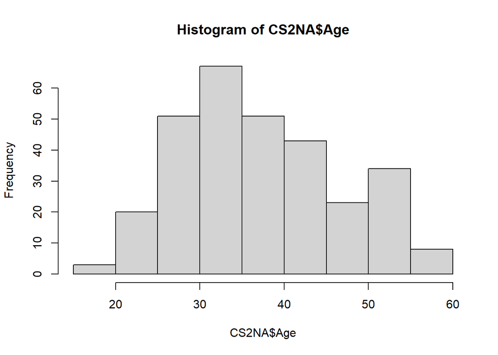

```r
tenure1NA <- max(CS2NA$YearsAtCompany)
#tenure1NA

hist(CS2NA$Age)
hist(CS2NA$Age)
```

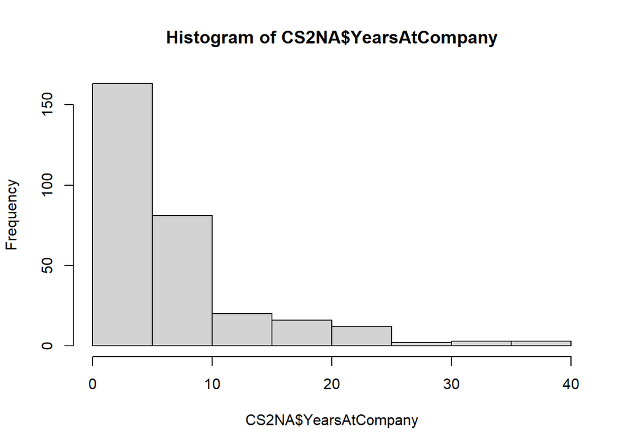

```r
hist(CS2NA$YearsAtCompany)
```

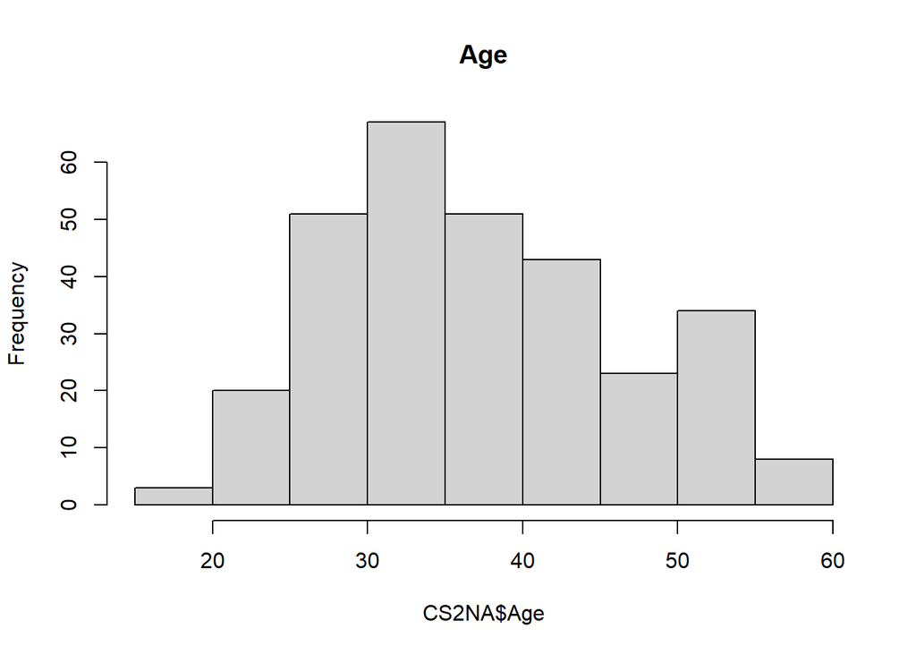

```r
hist(CS2NA$Age, main = "Age")
```

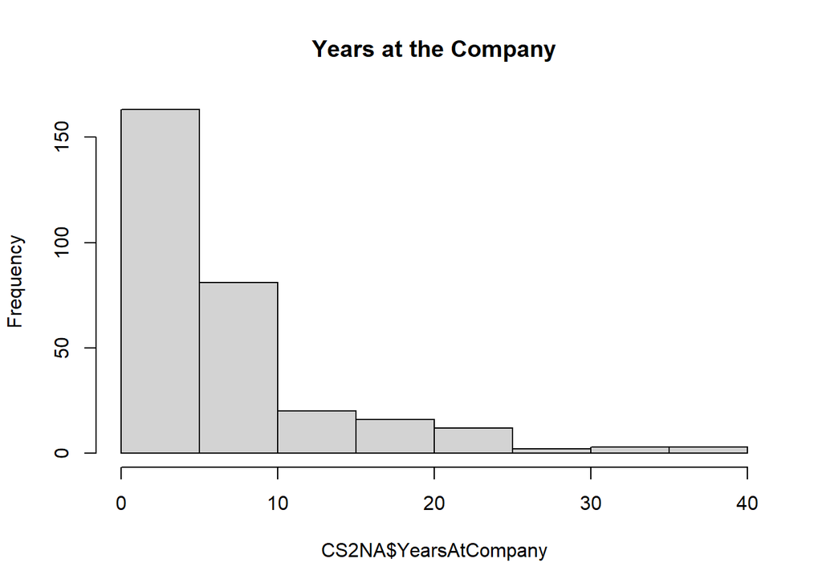

```r
hist(CS2NA$YearsAtCompany, main = "Years at the Company")
```

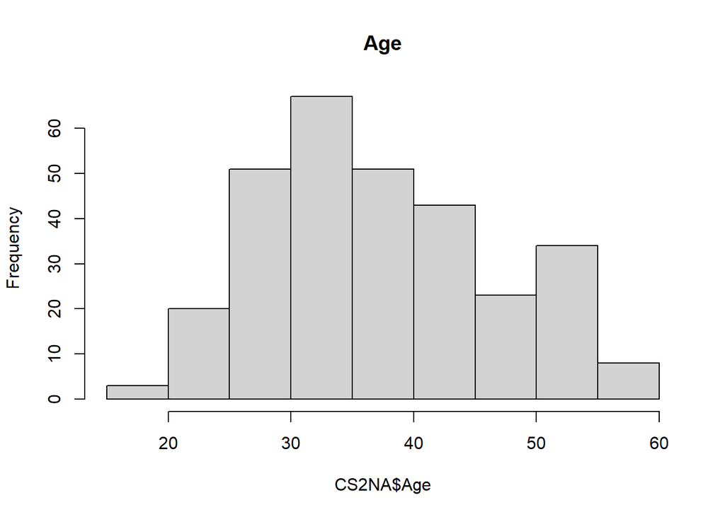

```r
hist(CS2NA$Age, main = "Age")
```

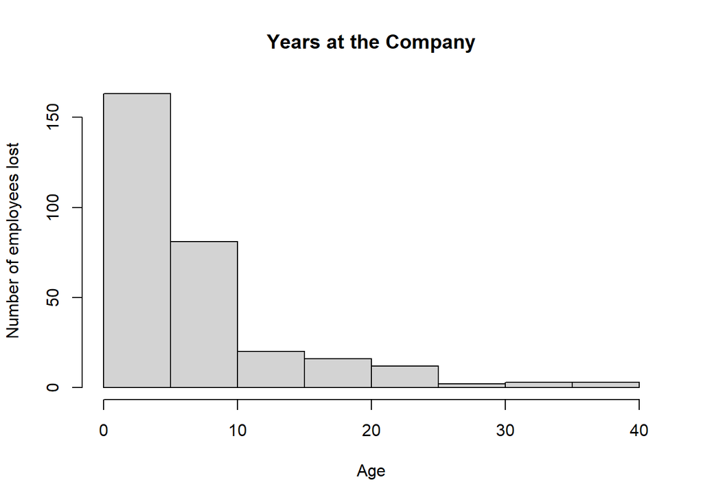

```r
hist(CS2NA$YearsAtCompany, main = "Years at the Company", xlab = "Age", ylab = "Number of employees lost")
```

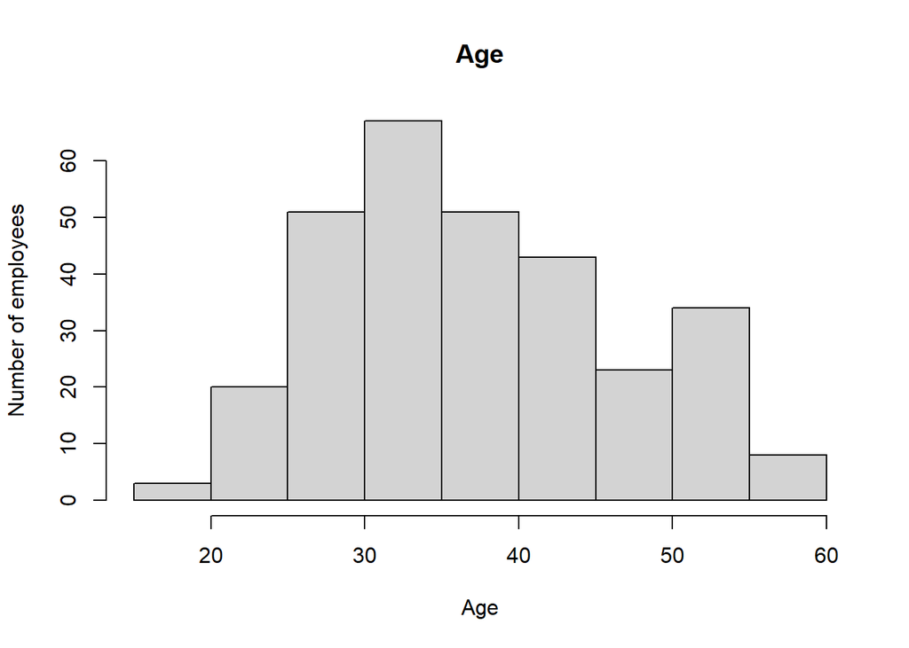

```r
hist(CS2NA$Age, main = "Age", xlab = "Age", ylab = "Number of employees")
```

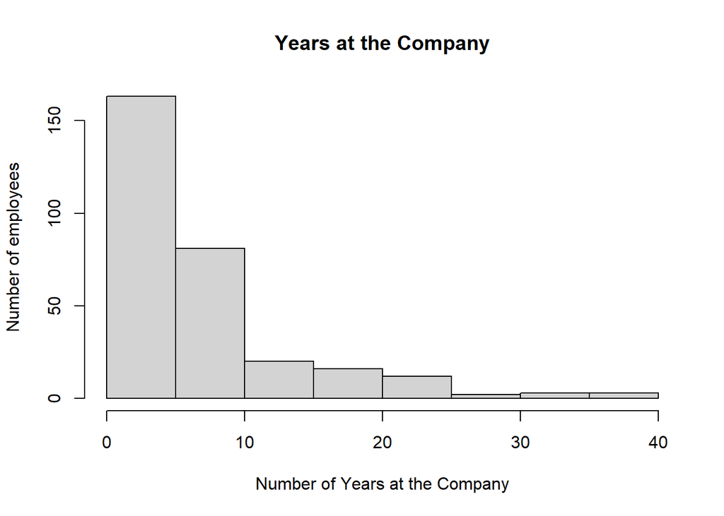

```r
hist(CS2NA$YearsAtCompany, main = "Years at the Company", xlab = "Number of Years at the Company", ylab = "Number of employees")
```

```r
summary(CS2NA$Age)
```

```
##    Min. 1st Qu.  Median    Mean 3rd Qu.    Max.
##   19.00   31.00   36.00   37.86   44.00   60.00
```

```r
summary(CS2NA$YearsAtCompany)
```

```
##    Min. 1st Qu.  Median    Mean 3rd Qu.    Max.
##   0.000   3.000   5.000   7.527  10.000  37.000
```

```r
t.test(CS2NA$Age)
```

```
##
##  One Sample t-test
##
## data:  CS2NA$Age
## t = 68.224, df = 299, p-value < 2.2e-16
## alternative hypothesis: true mean is not equal to 0
## 95 percent confidence interval:
##  36.76468 38.94865
## sample estimates:
## mean of x
##  37.85667
```

```r
t.test(CS2NA$YearsAtCompany)
```

```
##
##  One Sample t-test
##
## data:  CS2NA$YearsAtCompany
## t = 18.866, df = 299, p-value < 2.2e-16
## alternative hypothesis: true mean is not equal to 0
## 95 percent confidence interval:
##  6.741560 8.311773
## sample estimates:
## mean of x
##  7.526667
```

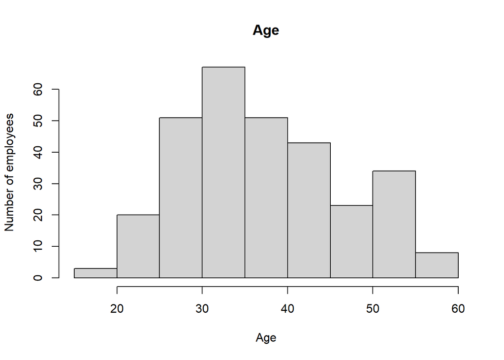

```r
hist(CS2NA$Age, main = "Age", xlab = "Age", ylab = "Number of employees")
```

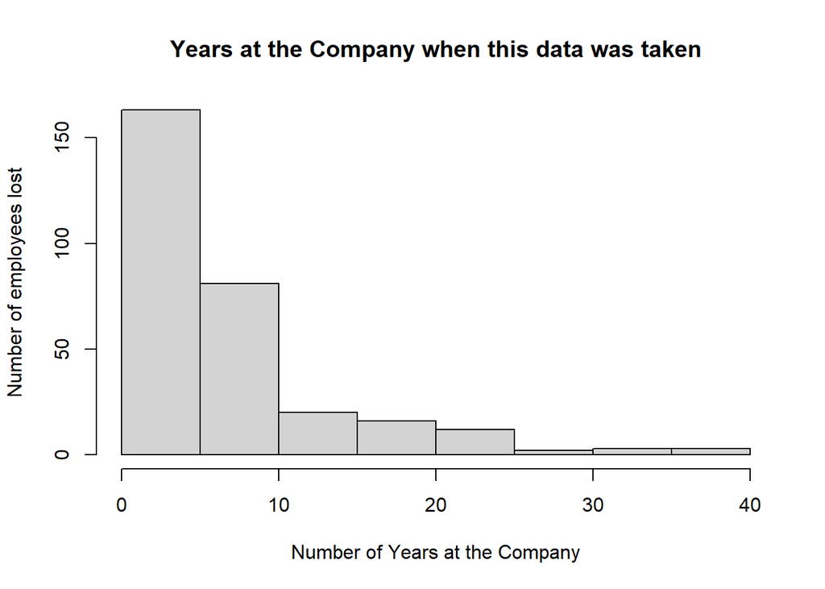

```r
hist(CS2NA$YearsAtCompany, main = "Years at the Company when this data was taken", xlab = "Number of Years at the Company", ylab = "Number of employees lost")
```

```r
summary(CS2NA$Age)
```

```
##    Min. 1st Qu.  Median    Mean 3rd Qu.    Max.
##   19.00   31.00   36.00   37.86   44.00   60.00
```

```r
summary(CS2NA$YearsAtCompany)
```

```
##    Min. 1st Qu.  Median    Mean 3rd Qu.    Max.
##   0.000   3.000   5.000   7.527  10.000  37.000
```

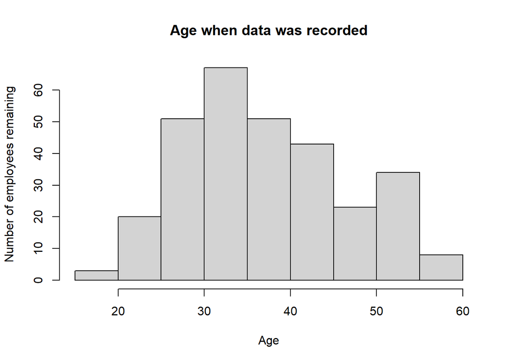

```r
hist(CS2NA$Age, main = "Age when data was recorded", xlab = "Age", ylab = "Number of employees remaining")
```

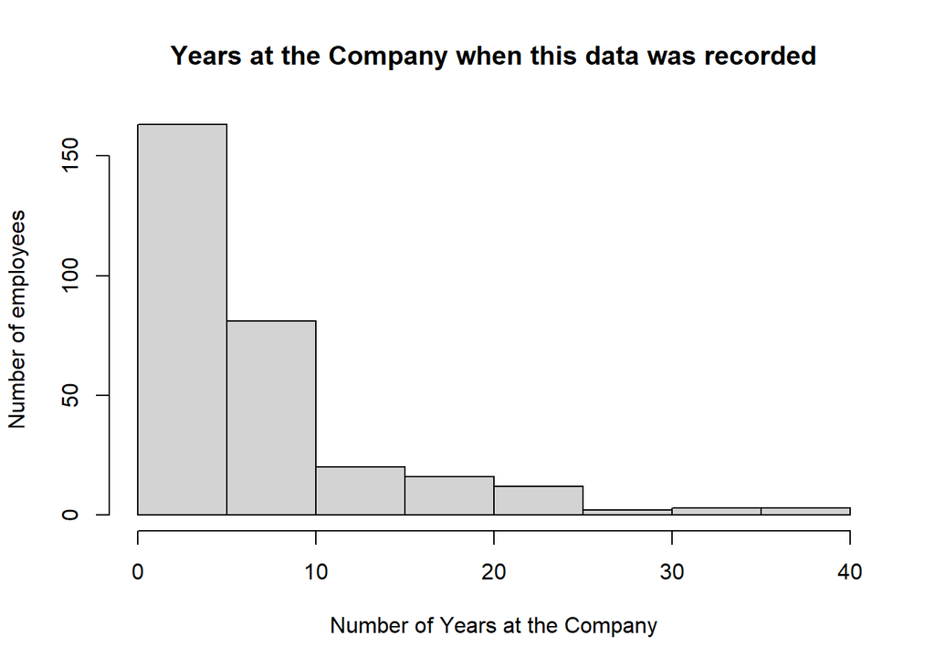

```r
hist(CS2NA$YearsAtCompany, main = "Years at the Company when this data was recorded", xlab = "Number of Years at the Company", ylab = "Number of employees")
```

```r
summary(CS2NA$Age)
```

```
##    Min. 1st Qu.  Median    Mean 3rd Qu.    Max.
##   19.00   31.00   36.00   37.86   44.00   60.00
```

```r
summary(CS2NA$YearsAtCompany)
```

```
##    Min. 1st Qu.  Median    Mean 3rd Qu.    Max.
##   0.000   3.000   5.000   7.527  10.000  37.000
```

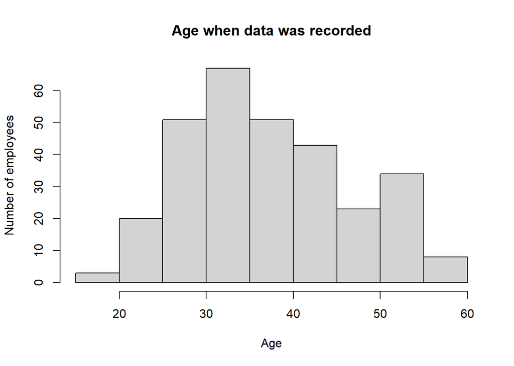

```r
hist(CS2NA$Age, main = "Age when data was recorded", xlab = "Age", ylab = "Number of employees")
```

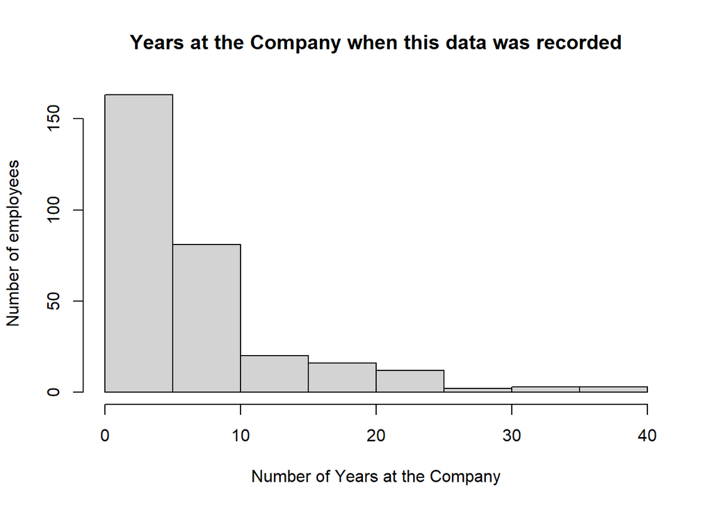

```r
hist(CS2NA$YearsAtCompany, main = "Years at the Company when this data was recorded", xlab = "Number of Years at the Company", ylab = "Number of employees")
```

```r
summary(CS2NA$Age)
```

```
##    Min. 1st Qu.  Median    Mean 3rd Qu.    Max.
##   19.00   31.00   36.00   37.86   44.00   60.00
```

```r
summary(CS2NA$YearsAtCompany)
```

```
##    Min. 1st Qu.  Median    Mean 3rd Qu.    Max.
##   0.000   3.000   5.000   7.527  10.000  37.000
```

```r
t.test(CS2NA$Age)
```

```
##
##  One Sample t-test
##
## data:  CS2NA$Age
## t = 68.224, df = 299, p-value < 2.2e-16
## alternative hypothesis: true mean is not equal to 0
## 95 percent confidence interval:
##  36.76468 38.94865
## sample estimates:
## mean of x
##  37.85667
```

```r
t.test(CS2NA$YearsAtCompany)
```

```
##
##  One Sample t-test
##
## data:  CS2NA$YearsAtCompany
## t = 18.866, df = 299, p-value < 2.2e-16
## alternative hypothesis: true mean is not equal to 0
## 95 percent confidence interval:
##  6.741560 8.311773
## sample estimates:
## mean of x
##  7.526667
```

We have one useful data set. CS2NA - all data. From here, we continue cleaning up the data set to apply it as the test set against the training set from the prior data set.

```r
KNN_ALLNA <- CS2NA
#View(KNN_ALLNA)
```

Now we have a new data.frame with all 300 observations. Perhaps we should deal with missing values. Once again, there appear to be no missing values. So, there are a few columns that have binary values. We can change those to 0 and 1. All employees are/were over 18 and EmployeeCount is always 1. Those columns adds no value so we should drop them. There are 5 columns with multiple characters in categories. For now, I’m going to drop those columns out of the data.frame.

```r
summary(KNN_ALLNA)
```

```
##        ID            Age        BusinessTravel       DailyRate
##  Min.   :1171   Min.   :19.00   Length:300         Min.   : 102.0
##  1st Qu.:1246   1st Qu.:31.00   Class :character   1st Qu.: 448.0
##  Median :1320   Median :36.00   Mode  :character   Median : 775.0
##  Mean   :1320   Mean   :37.86                      Mean   : 784.8
##  3rd Qu.:1395   3rd Qu.:44.00                      3rd Qu.:1117.0
##  Max.   :1470   Max.   :60.00                      Max.   :1490.0
##   Department        DistanceFromHome   Education     EducationField
##  Length:300         Min.   : 1.00    Min.   :1.000   Length:300
##  Class :character   1st Qu.: 2.00    1st Qu.:2.000   Class :character
##  Mode  :character   Median : 7.00    Median :3.000   Mode  :character
##                     Mean   : 9.26    Mean   :2.973
##                     3rd Qu.:14.00    3rd Qu.:4.000
##                     Max.   :29.00    Max.   :5.000
##  EmployeeCount EmployeeNumber   EnvironmentSatisfaction    Gender
##  Min.   :1     Min.   :   2.0   Min.   :1.000           Length:300
##  1st Qu.:1     1st Qu.: 508.8   1st Qu.:2.000           Class :character
##  Median :1     Median : 994.5   Median :3.000           Mode  :character
##  Mean   :1     Mean   :1020.9   Mean   :2.733
##  3rd Qu.:1     3rd Qu.:1542.5   3rd Qu.:4.000
##  Max.   :1     Max.   :2065.0   Max.   :4.000
##    HourlyRate     JobInvolvement     JobLevel     JobRole
##  Min.   : 30.00   Min.   :1.000   Min.   :1.0   Length:300
##  1st Qu.: 50.00   1st Qu.:2.000   1st Qu.:1.0   Class :character
##  Median : 66.00   Median :3.000   Median :2.0   Mode  :character
##  Mean   : 66.07   Mean   :2.743   Mean   :2.2
##  3rd Qu.: 83.00   3rd Qu.:3.000   3rd Qu.:3.0
##  Max.   :100.00   Max.   :4.000   Max.   :5.0
##  JobSatisfaction MaritalStatus      MonthlyIncome    MonthlyRate
##  Min.   :1.000   Length:300         Min.   : 1232   Min.   : 2097
##  1st Qu.:2.000   Class :character   1st Qu.: 3034   1st Qu.: 8420
##  Median :3.000   Mode  :character   Median : 5208   Median :15091
##  Mean   :2.767                      Mean   : 7103   Mean   :14499
##  3rd Qu.:4.000                      3rd Qu.: 9750   3rd Qu.:20330
##  Max.   :4.000                      Max.   :19973   Max.   :26914
##  NumCompaniesWorked    Over18            OverTime         PercentSalaryHike
##  Min.   :0.000      Length:300         Length:300         Min.   :11.00
##  1st Qu.:1.000      Class :character   Class :character   1st Qu.:12.00
##  Median :2.000      Mode  :character   Mode  :character   Median :14.00
##  Mean   :2.547                                            Mean   :15.17
```

[output cut: 8 more lines]

```
##  Max.   :4.000     Max.   :4.000            Max.   :80    Max.   :3.0000
##  TotalWorkingYears TrainingTimesLastYear WorkLifeBalance YearsAtCompany
##  Min.   : 0.00     Min.   :0.000         Min.   :1.000   Min.   : 0.000
##  1st Qu.: 6.00     1st Qu.:2.000         1st Qu.:2.000   1st Qu.: 3.000
##  Median :10.00     Median :2.000         Median :3.000   Median : 5.000
##  Mean   :12.44     Mean   :2.683         Mean   :2.747   Mean   : 7.527
##  3rd Qu.:18.00     3rd Qu.:3.000         3rd Qu.:3.000   3rd Qu.:10.000
##  Max.   :38.00     Max.   :6.000         Max.   :4.000   Max.   :37.000
##  YearsInCurrentRole YearsSinceLastPromotion YearsWithCurrManager
##  Min.   : 0.00      Min.   : 0.00           Min.   : 0.00
##  1st Qu.: 2.00      1st Qu.: 0.00           1st Qu.: 2.00
##  Median : 3.00      Median : 1.00           Median : 3.00
##  Mean   : 4.33      Mean   : 2.29           Mean   : 4.38
##  3rd Qu.: 7.00      3rd Qu.: 3.00           3rd Qu.: 7.00
##  Max.   :18.00      Max.   :15.00           Max.   :17.00
```

```r
sum(is.na(KNN_ALLNA))
```

```
## [1] 0
```

```r
#convert binary columns to 1s and 0s.

KNN_ALLNA$Gender <- str_replace(KNN_ALLNA$Gender,"Female", "1")
KNN_ALLNA$Gender <- str_replace(KNN_ALLNA$Gender,"Male", "0")
#KNN_ALLNA$Gender
KNN_ALLNA$OverTime <- str_replace(KNN_ALLNA$OverTime,"Yes", "1")
KNN_ALLNA$OverTime <- str_replace(KNN_ALLNA$OverTime,"No", "0")
#KNN_ALLNA$OverTime
KNN_ALLNA$OverTime <- str_replace(KNN_ALLNA$OverTime,"Yes", "1")
KNN_ALLNA$OverTime <- str_replace(KNN_ALLNA$OverTime,"No", "0")
#KNN_ALLNA$OverTime

#Remove the BusinessTravel, Department, EducationField, JobRole, MaritalStatus columns. These have multiple categorical values that we can return to if necessary.
KNN_ALLNA[ , c('BusinessTravel', 'Department', 'EducationField', 'JobRole', 'MaritalStatus')] <- list(NULL)
#View(KNN_ALLNA)
KNN_ALLNA[ , c('Over18', 'EmployeeCount')] <- list(NULL)
#View(KNN_ALLNA)
summary(KNN_ALLNA)
```

```
##        ID            Age          DailyRate      DistanceFromHome
##  Min.   :1171   Min.   :19.00   Min.   : 102.0   Min.   : 1.00
##  1st Qu.:1246   1st Qu.:31.00   1st Qu.: 448.0   1st Qu.: 2.00
##  Median :1320   Median :36.00   Median : 775.0   Median : 7.00
##  Mean   :1320   Mean   :37.86   Mean   : 784.8   Mean   : 9.26
##  3rd Qu.:1395   3rd Qu.:44.00   3rd Qu.:1117.0   3rd Qu.:14.00
##  Max.   :1470   Max.   :60.00   Max.   :1490.0   Max.   :29.00
##    Education     EmployeeNumber   EnvironmentSatisfaction    Gender
##  Min.   :1.000   Min.   :   2.0   Min.   :1.000           Length:300
##  1st Qu.:2.000   1st Qu.: 508.8   1st Qu.:2.000           Class :character
##  Median :3.000   Median : 994.5   Median :3.000           Mode  :character
##  Mean   :2.973   Mean   :1020.9   Mean   :2.733
##  3rd Qu.:4.000   3rd Qu.:1542.5   3rd Qu.:4.000
##  Max.   :5.000   Max.   :2065.0   Max.   :4.000
##    HourlyRate     JobInvolvement     JobLevel   JobSatisfaction MonthlyIncome
##  Min.   : 30.00   Min.   :1.000   Min.   :1.0   Min.   :1.000   Min.   : 1232
##  1st Qu.: 50.00   1st Qu.:2.000   1st Qu.:1.0   1st Qu.:2.000   1st Qu.: 3034
##  Median : 66.00   Median :3.000   Median :2.0   Median :3.000   Median : 5208
##  Mean   : 66.07   Mean   :2.743   Mean   :2.2   Mean   :2.767   Mean   : 7103
##  3rd Qu.: 83.00   3rd Qu.:3.000   3rd Qu.:3.0   3rd Qu.:4.000   3rd Qu.: 9750
##  Max.   :100.00   Max.   :4.000   Max.   :5.0   Max.   :4.000   Max.   :19973
##   MonthlyRate    NumCompaniesWorked   OverTime         PercentSalaryHike
##  Min.   : 2097   Min.   :0.000      Length:300         Min.   :11.00
##  1st Qu.: 8420   1st Qu.:1.000      Class :character   1st Qu.:12.00
##  Median :15091   Median :2.000      Mode  :character   Median :14.00
##  Mean   :14499   Mean   :2.547                         Mean   :15.17
##  3rd Qu.:20330   3rd Qu.:4.000                         3rd Qu.:18.00
##  Max.   :26914   Max.   :9.000                         Max.   :25.00
##  PerformanceRating RelationshipSatisfaction StandardHours StockOptionLevel
##  Min.   :3.000     Min.   :1.000            Min.   :80    Min.   :0.0000
##  1st Qu.:3.000     1st Qu.:2.000            1st Qu.:80    1st Qu.:0.0000
##  Median :3.000     Median :3.000            Median :80    Median :1.0000
##  Mean   :3.153     Mean   :2.803            Mean   :80    Mean   :0.7833
##  3rd Qu.:3.000     3rd Qu.:4.000            3rd Qu.:80    3rd Qu.:1.0000
##  Max.   :4.000     Max.   :4.000            Max.   :80    Max.   :3.0000
##  TotalWorkingYears TrainingTimesLastYear WorkLifeBalance YearsAtCompany
##  Min.   : 0.00     Min.   :0.000         Min.   :1.000   Min.   : 0.000
##  1st Qu.: 6.00     1st Qu.:2.000         1st Qu.:2.000   1st Qu.: 3.000
##  Median :10.00     Median :2.000         Median :3.000   Median : 5.000
##  Mean   :12.44     Mean   :2.683         Mean   :2.747   Mean   : 7.527
##  3rd Qu.:18.00     3rd Qu.:3.000         3rd Qu.:3.000   3rd Qu.:10.000
##  Max.   :38.00     Max.   :6.000         Max.   :4.000   Max.   :37.000
##  YearsInCurrentRole YearsSinceLastPromotion YearsWithCurrManager
##  Min.   : 0.00      Min.   : 0.00           Min.   : 0.00
##  1st Qu.: 2.00      1st Qu.: 0.00           1st Qu.: 2.00
##  Median : 3.00      Median : 1.00           Median : 3.00
##  Mean   : 4.33      Mean   : 2.29           Mean   : 4.38
##  3rd Qu.: 7.00      3rd Qu.: 3.00           3rd Qu.: 7.00
##  Max.   :18.00      Max.   :15.00           Max.   :17.00
```

We need to convert all character columns to numeric

```r
KNN_ALLNA$Gender <- as.numeric(KNN_ALLNA$Gender)
KNN_ALLNA$OverTime <- as.numeric(KNN_ALLNA$OverTime)
summary(KNN_ALLNA)
```

```
##        ID            Age          DailyRate      DistanceFromHome
##  Min.   :1171   Min.   :19.00   Min.   : 102.0   Min.   : 1.00
##  1st Qu.:1246   1st Qu.:31.00   1st Qu.: 448.0   1st Qu.: 2.00
##  Median :1320   Median :36.00   Median : 775.0   Median : 7.00
##  Mean   :1320   Mean   :37.86   Mean   : 784.8   Mean   : 9.26
##  3rd Qu.:1395   3rd Qu.:44.00   3rd Qu.:1117.0   3rd Qu.:14.00
##  Max.   :1470   Max.   :60.00   Max.   :1490.0   Max.   :29.00
##    Education     EmployeeNumber   EnvironmentSatisfaction     Gender
##  Min.   :1.000   Min.   :   2.0   Min.   :1.000           Min.   :0.00
##  1st Qu.:2.000   1st Qu.: 508.8   1st Qu.:2.000           1st Qu.:0.00
##  Median :3.000   Median : 994.5   Median :3.000           Median :0.00
##  Mean   :2.973   Mean   :1020.9   Mean   :2.733           Mean   :0.35
##  3rd Qu.:4.000   3rd Qu.:1542.5   3rd Qu.:4.000           3rd Qu.:1.00
##  Max.   :5.000   Max.   :2065.0   Max.   :4.000           Max.   :1.00
##    HourlyRate     JobInvolvement     JobLevel   JobSatisfaction MonthlyIncome
##  Min.   : 30.00   Min.   :1.000   Min.   :1.0   Min.   :1.000   Min.   : 1232
##  1st Qu.: 50.00   1st Qu.:2.000   1st Qu.:1.0   1st Qu.:2.000   1st Qu.: 3034
##  Median : 66.00   Median :3.000   Median :2.0   Median :3.000   Median : 5208
##  Mean   : 66.07   Mean   :2.743   Mean   :2.2   Mean   :2.767   Mean   : 7103
##  3rd Qu.: 83.00   3rd Qu.:3.000   3rd Qu.:3.0   3rd Qu.:4.000   3rd Qu.: 9750
##  Max.   :100.00   Max.   :4.000   Max.   :5.0   Max.   :4.000   Max.   :19973
##   MonthlyRate    NumCompaniesWorked    OverTime      PercentSalaryHike
##  Min.   : 2097   Min.   :0.000      Min.   :0.0000   Min.   :11.00
##  1st Qu.: 8420   1st Qu.:1.000      1st Qu.:0.0000   1st Qu.:12.00
##  Median :15091   Median :2.000      Median :0.0000   Median :14.00
##  Mean   :14499   Mean   :2.547      Mean   :0.2933   Mean   :15.17
##  3rd Qu.:20330   3rd Qu.:4.000      3rd Qu.:1.0000   3rd Qu.:18.00
##  Max.   :26914   Max.   :9.000      Max.   :1.0000   Max.   :25.00
##  PerformanceRating RelationshipSatisfaction StandardHours StockOptionLevel
##  Min.   :3.000     Min.   :1.000            Min.   :80    Min.   :0.0000
##  1st Qu.:3.000     1st Qu.:2.000            1st Qu.:80    1st Qu.:0.0000
##  Median :3.000     Median :3.000            Median :80    Median :1.0000
##  Mean   :3.153     Mean   :2.803            Mean   :80    Mean   :0.7833
##  3rd Qu.:3.000     3rd Qu.:4.000            3rd Qu.:80    3rd Qu.:1.0000
##  Max.   :4.000     Max.   :4.000            Max.   :80    Max.   :3.0000
##  TotalWorkingYears TrainingTimesLastYear WorkLifeBalance YearsAtCompany
##  Min.   : 0.00     Min.   :0.000         Min.   :1.000   Min.   : 0.000
##  1st Qu.: 6.00     1st Qu.:2.000         1st Qu.:2.000   1st Qu.: 3.000
##  Median :10.00     Median :2.000         Median :3.000   Median : 5.000
##  Mean   :12.44     Mean   :2.683         Mean   :2.747   Mean   : 7.527
##  3rd Qu.:18.00     3rd Qu.:3.000         3rd Qu.:3.000   3rd Qu.:10.000
##  Max.   :38.00     Max.   :6.000         Max.   :4.000   Max.   :37.000
##  YearsInCurrentRole YearsSinceLastPromotion YearsWithCurrManager
##  Min.   : 0.00      Min.   : 0.00           Min.   : 0.00
##  1st Qu.: 2.00      1st Qu.: 0.00           1st Qu.: 2.00
##  Median : 3.00      Median : 1.00           Median : 3.00
##  Mean   : 4.33      Mean   : 2.29           Mean   : 4.38
##  3rd Qu.: 7.00      3rd Qu.: 3.00           3rd Qu.: 7.00
##  Max.   :18.00      Max.   :15.00           Max.   :17.00
```

```r
str(KNN_ALLNA)
```

```
## tibble [300 × 28] (S3: tbl_df/tbl/data.frame)
##  $ ID                      : num [1:300] 1171 1172 1173 1174 1175 ...
##  $ Age                     : num [1:300] 35 33 26 55 29 51 52 39 31 31 ...
##  $ DailyRate               : num [1:300] 750 147 1330 1311 1246 ...
##  $ DistanceFromHome        : num [1:300] 28 2 21 2 19 1 29 10 24 20 ...
##  $ Education               : num [1:300] 3 3 3 3 3 4 4 5 3 3 ...
##  $ EmployeeNumber          : num [1:300] 1596 1207 1107 505 1497 ...
##  $ EnvironmentSatisfaction : num [1:300] 2 2 1 3 3 1 1 2 3 1 ...
##  $ Gender                  : num [1:300] 0 0 0 1 0 1 0 0 1 0 ...
##  $ HourlyRate              : num [1:300] 46 99 37 97 77 30 40 76 96 66 ...
##  $ JobInvolvement          : num [1:300] 4 3 3 3 2 2 3 3 2 3 ...
##  $ JobLevel                : num [1:300] 2 1 1 4 2 3 1 2 2 3 ...
##  $ JobSatisfaction         : num [1:300] 3 3 3 4 3 1 4 1 1 3 ...
##  $ MonthlyIncome           : num [1:300] 3407 3600 2377 16659 8620 ...
##  $ MonthlyRate             : num [1:300] 25348 8429 19373 23258 23757 ...
##  $ NumCompaniesWorked      : num [1:300] 1 1 1 2 1 3 2 2 1 3 ...
##  $ OverTime                : num [1:300] 0 0 0 1 0 0 0 0 0 0 ...
##  $ PercentSalaryHike       : num [1:300] 17 13 20 13 14 20 15 13 19 12 ...
##  $ PerformanceRating       : num [1:300] 3 3 4 3 3 4 3 3 3 3 ...
##  $ RelationshipSatisfaction: num [1:300] 4 4 3 3 3 3 2 4 2 1 ...
##  $ StandardHours           : num [1:300] 80 80 80 80 80 80 80 80 80 80 ...
##  $ StockOptionLevel        : num [1:300] 2 1 1 0 2 0 2 3 0 0 ...
##  $ TotalWorkingYears       : num [1:300] 10 5 1 30 10 23 16 10 10 12 ...
##  $ TrainingTimesLastYear   : num [1:300] 3 2 0 2 3 1 3 3 2 2 ...
##  $ WorkLifeBalance         : num [1:300] 2 3 2 3 3 2 2 3 3 3 ...
##  $ YearsAtCompany          : num [1:300] 10 5 1 5 10 13 9 7 10 1 ...
##  $ YearsInCurrentRole      : num [1:300] 9 4 1 4 7 12 8 7 9 0 ...
##  $ YearsSinceLastPromotion : num [1:300] 6 1 0 1 0 12 0 7 1 0 ...
##  $ YearsWithCurrManager    : num [1:300] 8 4 0 2 4 8 0 7 8 0 ...
```

All columns are numeric. Now, we need to scale all columns. But, first remove the binary columns.

```r
KNN_ALLNA[ , c('EmployeeCount', 'Gender', 'OverTime')] <- list(NULL)
#View(KNN_ALLNA)

KNN_ALLNA_standardize <- as.data.frame(scale(KNN_ALLNA)) #, KNN_ALL[4:6], KNN_ALL[8:9], KNN_ALL[11:17], KNN_ALL[19:30]))
#View(KNN_ALLNA_standardize)
```

```r
KNN_ALLNA_standardize <- cbind(CS2NA$EmployeeCount, CS2NA$Gender, CS2NA$OverTime, KNN_ALLNA_standardize)
#View(KNN_ALLNA_standardize)

colnames(KNN_ALLNA_standardize)[colnames(KNN_ALLNA_standardize) == 'CS2NA$OverTime'] <- 'OverTime'
colnames(KNN_ALLNA_standardize)[colnames(KNN_ALLNA_standardize) == 'CS2NA$Gender'] <- 'Gender'


KNN_ALLNA_standardize$Gender <- str_replace(KNN_ALLNA_standardize$Gender,"Female", "1")
KNN_ALLNA_standardize$Gender <- str_replace(KNN_ALLNA_standardize$Gender,"Male", "0")
#KNN_ALLNA_standardize$Gender
KNN_ALLNA_standardize$OverTime <- str_replace(KNN_ALLNA_standardize$OverTime,"Yes", "1")
KNN_ALLNA_standardize$OverTime <- str_replace(KNN_ALLNA_standardize$OverTime,"No", "0")
#KNN_ALLNA_standardize$OverTime
KNN_ALLNA_standardize$OverTime <- str_replace(KNN_ALLNA_standardize$OverTime,"Yes", "1")
KNN_ALLNA_standardize$OverTime <- str_replace(KNN_ALLNA_standardize$OverTime,"No", "0")
#KNN_ALLNA_standardize$OverTime

colnames(KNN_ALLNA_standardize)[colnames(KNN_ALLNA_standardize) == 'CS2NA$OverTime'] <- 'OverTime'
colnames(KNN_ALLNA_standardize)[colnames(KNN_ALLNA_standardize) == 'CS2NA$Gender'] <- 'Gender'

#I inadvertently added back EmployeeCount, so it must be removed
KNN_ALLNA_standardize[ , c('CS2NA$EmployeeCount')] <- list(NULL)
#View(KNN_ALLNA_standardize)


#head(KNN_ALLNA_standardize)
str(KNN_ALLNA_standardize)
```

```
## 'data.frame':    300 obs. of  28 variables:
##  $ Gender                  : chr  "0" "0" "0" "1" ...
##  $ OverTime                : chr  "0" "0" "0" "1" ...
##  $ ID                      : num  -1.72 -1.71 -1.7 -1.69 -1.68 ...
##  $ Age                     : num  -0.297 -0.505 -1.234 1.784 -0.922 ...
##  $ DailyRate               : num  -0.086 -1.578 1.349 1.302 1.141 ...
##  $ DistanceFromHome        : num  2.19 -0.85 1.37 -0.85 1.14 ...
##  $ Education               : num  0.0265 0.0265 0.0265 0.0265 0.0265 ...
##  $ EmployeeNumber          : num  0.984 0.318 0.147 -0.883 0.815 ...
##  $ EnvironmentSatisfaction : num  -0.681 -0.681 -1.61 0.248 0.248 ...
##  $ HourlyRate              : num  -0.994 1.631 -1.439 1.532 0.541 ...
##  $ JobInvolvement          : num  1.68 0.343 0.343 0.343 -0.994 ...
##  $ JobLevel                : num  -0.162 -0.97 -0.97 1.454 -0.162 ...
##  $ JobSatisfaction         : num  0.216 0.216 0.216 1.14 0.216 ...
##  $ MonthlyIncome           : num  -0.698 -0.661 -0.892 1.803 0.286 ...
##  $ MonthlyRate             : num  1.519 -0.85 0.682 1.226 1.296 ...
##  $ NumCompaniesWorked      : num  -0.658 -0.658 -0.658 -0.233 -0.658 ...
##  $ PercentSalaryHike       : num  0.506 -0.598 1.333 -0.598 -0.322 ...
##  $ PerformanceRating       : num  -0.425 -0.425 2.346 -0.425 -0.425 ...
##  $ RelationshipSatisfaction: num  1.16 1.16 0.19 0.19 0.19 ...
##  $ StandardHours           : num  NaN NaN NaN NaN NaN NaN NaN NaN NaN NaN ...
##  $ StockOptionLevel        : num  1.403 0.25 0.25 -0.903 1.403 ...
##  $ TotalWorkingYears       : num  -0.284 -0.867 -1.334 2.048 -0.284 ...
##  $ TrainingTimesLastYear   : num  0.246 -0.53 -2.081 -0.53 0.246 ...
##  $ WorkLifeBalance         : num  -1.081 0.367 -1.081 0.367 0.367 ...
##  $ YearsAtCompany          : num  0.358 -0.366 -0.945 -0.366 0.358 ...
##  $ YearsInCurrentRole      : num  1.3261 -0.0937 -0.9456 -0.0937 0.7582 ...
##  $ YearsSinceLastPromotion : num  1.088 -0.378 -0.672 -0.378 -0.672 ...
##  $ YearsWithCurrManager    : num  0.9287 -0.0975 -1.1237 -0.6106 -0.0975 ...
```

I had to rename the first two columns to the appropriate names and then change them to numeric. Gender and OverTime.

```r
KNN_ALLNA_standardize$Gender <- as.numeric(KNN_ALLNA_standardize$Gender)
KNN_ALLNA_standardize$OverTime <- as.numeric(KNN_ALLNA_standardize$OverTime)
summary(KNN_ALLNA_standardize)
```

```
##      Gender        OverTime            ID               Age
##  Min.   :0.00   Min.   :0.0000   Min.   :-1.7234   Min.   :-1.9620
##  1st Qu.:0.00   1st Qu.:0.0000   1st Qu.:-0.8617   1st Qu.:-0.7134
##  Median :0.00   Median :0.0000   Median : 0.0000   Median :-0.1932
##  Mean   :0.35   Mean   :0.2933   Mean   : 0.0000   Mean   : 0.0000
##  3rd Qu.:1.00   3rd Qu.:1.0000   3rd Qu.: 0.8617   3rd Qu.: 0.6392
##  Max.   :1.00   Max.   :1.0000   Max.   : 1.7234   Max.   : 2.3040
##
##    DailyRate        DistanceFromHome    Education        EmployeeNumber
##  Min.   :-1.68947   Min.   :-0.9673   Min.   :-1.95772   Min.   :-1.74350
##  1st Qu.:-0.83332   1st Qu.:-0.8502   1st Qu.:-0.96563   1st Qu.:-0.87637
##  Median :-0.02418   Median :-0.2647   Median : 0.02646   Median :-0.04517
##  Mean   : 0.00000   Mean   : 0.0000   Mean   : 0.00000   Mean   : 0.00000
##  3rd Qu.: 0.82207   3rd Qu.: 0.5551   3rd Qu.: 1.01855   3rd Qu.: 0.89254
##  Max.   : 1.74503   Max.   : 2.3116   Max.   : 2.01064   Max.   : 1.78662
##
##  EnvironmentSatisfaction   HourlyRate        JobInvolvement
##  Min.   :-1.6098         Min.   :-1.785766   Min.   :-2.3310
##  1st Qu.:-0.6811         1st Qu.:-0.795508   1st Qu.:-0.9939
##  Median : 0.2477         Median :-0.003301   Median : 0.3432
##  Mean   : 0.0000         Mean   : 0.000000   Mean   : 0.0000
##  3rd Qu.: 1.1764         3rd Qu.: 0.838419   3rd Qu.: 0.3432
##  Max.   : 1.1764         Max.   : 1.680139   Max.   : 1.6803
##
##     JobLevel       JobSatisfaction   MonthlyIncome      MonthlyRate
##  Min.   :-0.9696   Min.   :-1.6337   Min.   :-1.1081   Min.   :-1.73603
##  1st Qu.:-0.9696   1st Qu.:-0.7089   1st Qu.:-0.7681   1st Qu.:-0.85100
##  Median :-0.1616   Median : 0.2158   Median :-0.3576   Median : 0.08281
##  Mean   : 0.0000   Mean   : 0.0000   Mean   : 0.0000   Mean   : 0.00000
##  3rd Qu.: 0.6464   3rd Qu.: 1.1405   3rd Qu.: 0.4995   3rd Qu.: 0.81610
##  Max.   : 2.2624   Max.   : 1.1405   Max.   : 2.4289   Max.   : 1.73773
##
##  NumCompaniesWorked PercentSalaryHike PerformanceRating
##  Min.   :-1.0840    Min.   :-1.1490   Min.   :-0.4249
##  1st Qu.:-0.6583    1st Qu.:-0.8733   1st Qu.:-0.4249
##  Median :-0.2327    Median :-0.3217   Median :-0.4249
##  Mean   : 0.0000    Mean   : 0.0000   Mean   : 0.0000
##  3rd Qu.: 0.6186    3rd Qu.: 0.7813   3rd Qu.:-0.4249
##  Max.   : 2.7468    Max.   : 2.7117   Max.   : 2.3459
##
```

[output cut: 9 more lines]

```
##  Min.   :-2.0815       Min.   :-2.5279   Min.   :-1.0892   Min.   :-1.2295
##  1st Qu.:-0.5301       1st Qu.:-1.0806   1st Qu.:-0.6551   1st Qu.:-0.6616
##  Median :-0.5301       Median : 0.3666   Median :-0.3657   Median :-0.3777
##  Mean   : 0.0000       Mean   : 0.0000   Mean   : 0.0000   Mean   : 0.0000
##  3rd Qu.: 0.2456       3rd Qu.: 0.3666   3rd Qu.: 0.3579   3rd Qu.: 0.7582
##  Max.   : 2.5727       Max.   : 1.8139   Max.   : 4.2653   Max.   : 3.8816
##
##  YearsSinceLastPromotion YearsWithCurrManager
##  Min.   :-0.6718         Min.   :-1.1237
##  1st Qu.:-0.6718         1st Qu.:-0.6106
##  Median :-0.3785         Median :-0.3540
##  Mean   : 0.0000         Mean   : 0.0000
##  3rd Qu.: 0.2083         3rd Qu.: 0.6722
##  Max.   : 3.7289         Max.   : 3.2377
##
```

```r
str(KNN_ALLNA_standardize)
```

```
## 'data.frame':    300 obs. of  28 variables:
##  $ Gender                  : num  0 0 0 1 0 1 0 0 1 0 ...
##  $ OverTime                : num  0 0 0 1 0 0 0 0 0 0 ...
##  $ ID                      : num  -1.72 -1.71 -1.7 -1.69 -1.68 ...
##  $ Age                     : num  -0.297 -0.505 -1.234 1.784 -0.922 ...
##  $ DailyRate               : num  -0.086 -1.578 1.349 1.302 1.141 ...
##  $ DistanceFromHome        : num  2.19 -0.85 1.37 -0.85 1.14 ...
##  $ Education               : num  0.0265 0.0265 0.0265 0.0265 0.0265 ...
##  $ EmployeeNumber          : num  0.984 0.318 0.147 -0.883 0.815 ...
##  $ EnvironmentSatisfaction : num  -0.681 -0.681 -1.61 0.248 0.248 ...
##  $ HourlyRate              : num  -0.994 1.631 -1.439 1.532 0.541 ...
##  $ JobInvolvement          : num  1.68 0.343 0.343 0.343 -0.994 ...
##  $ JobLevel                : num  -0.162 -0.97 -0.97 1.454 -0.162 ...
##  $ JobSatisfaction         : num  0.216 0.216 0.216 1.14 0.216 ...
##  $ MonthlyIncome           : num  -0.698 -0.661 -0.892 1.803 0.286 ...
##  $ MonthlyRate             : num  1.519 -0.85 0.682 1.226 1.296 ...
##  $ NumCompaniesWorked      : num  -0.658 -0.658 -0.658 -0.233 -0.658 ...
##  $ PercentSalaryHike       : num  0.506 -0.598 1.333 -0.598 -0.322 ...
##  $ PerformanceRating       : num  -0.425 -0.425 2.346 -0.425 -0.425 ...
##  $ RelationshipSatisfaction: num  1.16 1.16 0.19 0.19 0.19 ...
##  $ StandardHours           : num  NaN NaN NaN NaN NaN NaN NaN NaN NaN NaN ...
##  $ StockOptionLevel        : num  1.403 0.25 0.25 -0.903 1.403 ...
##  $ TotalWorkingYears       : num  -0.284 -0.867 -1.334 2.048 -0.284 ...
##  $ TrainingTimesLastYear   : num  0.246 -0.53 -2.081 -0.53 0.246 ...
##  $ WorkLifeBalance         : num  -1.081 0.367 -1.081 0.367 0.367 ...
##  $ YearsAtCompany          : num  0.358 -0.366 -0.945 -0.366 0.358 ...
##  $ YearsInCurrentRole      : num  1.3261 -0.0937 -0.9456 -0.0937 0.7582 ...
##  $ YearsSinceLastPromotion : num  1.088 -0.378 -0.672 -0.378 -0.672 ...
##  $ YearsWithCurrManager    : num  0.9287 -0.0975 -1.1237 -0.6106 -0.0975 ...
```

I wasn’t thinking when I took out EmployeeCount on the second set because now I have uneven sets. One with 29 columns and the other with 28. So, I’m going to remove EmployeeCount from the first set to even things up.

```r
KNN_ALL_standardize[ , c('EmployeeCount')] <- list(NULL)
#View(KNN_ALL_standardize)
```

I’ve noticed that StandardHours is all NaN and must be removed. That will once again make the data sets uneven. Which, of course, is as expected since one set has Attrition and the other doesn’t.

```r
KNN_ALLNA_standardize[ , c('StandardHours')] <- list(NULL)
#View(KNN_ALLNA_standardize)
str(KNN_ALLNA_standardize)
```

```
## 'data.frame':    300 obs. of  27 variables:
##  $ Gender                  : num  0 0 0 1 0 1 0 0 1 0 ...
##  $ OverTime                : num  0 0 0 1 0 0 0 0 0 0 ...
##  $ ID                      : num  -1.72 -1.71 -1.7 -1.69 -1.68 ...
##  $ Age                     : num  -0.297 -0.505 -1.234 1.784 -0.922 ...
##  $ DailyRate               : num  -0.086 -1.578 1.349 1.302 1.141 ...
##  $ DistanceFromHome        : num  2.19 -0.85 1.37 -0.85 1.14 ...
##  $ Education               : num  0.0265 0.0265 0.0265 0.0265 0.0265 ...
##  $ EmployeeNumber          : num  0.984 0.318 0.147 -0.883 0.815 ...
##  $ EnvironmentSatisfaction : num  -0.681 -0.681 -1.61 0.248 0.248 ...
##  $ HourlyRate              : num  -0.994 1.631 -1.439 1.532 0.541 ...
##  $ JobInvolvement          : num  1.68 0.343 0.343 0.343 -0.994 ...
##  $ JobLevel                : num  -0.162 -0.97 -0.97 1.454 -0.162 ...
##  $ JobSatisfaction         : num  0.216 0.216 0.216 1.14 0.216 ...
##  $ MonthlyIncome           : num  -0.698 -0.661 -0.892 1.803 0.286 ...
##  $ MonthlyRate             : num  1.519 -0.85 0.682 1.226 1.296 ...
##  $ NumCompaniesWorked      : num  -0.658 -0.658 -0.658 -0.233 -0.658 ...
##  $ PercentSalaryHike       : num  0.506 -0.598 1.333 -0.598 -0.322 ...
##  $ PerformanceRating       : num  -0.425 -0.425 2.346 -0.425 -0.425 ...
##  $ RelationshipSatisfaction: num  1.16 1.16 0.19 0.19 0.19 ...
##  $ StockOptionLevel        : num  1.403 0.25 0.25 -0.903 1.403 ...
##  $ TotalWorkingYears       : num  -0.284 -0.867 -1.334 2.048 -0.284 ...
##  $ TrainingTimesLastYear   : num  0.246 -0.53 -2.081 -0.53 0.246 ...
##  $ WorkLifeBalance         : num  -1.081 0.367 -1.081 0.367 0.367 ...
##  $ YearsAtCompany          : num  0.358 -0.366 -0.945 -0.366 0.358 ...
##  $ YearsInCurrentRole      : num  1.3261 -0.0937 -0.9456 -0.0937 0.7582 ...
##  $ YearsSinceLastPromotion : num  1.088 -0.378 -0.672 -0.378 -0.672 ...
##  $ YearsWithCurrManager    : num  0.9287 -0.0975 -1.1237 -0.6106 -0.0975 ...
```

```r
str(KNN_ALL_standardize)
```

```
## 'data.frame':    870 obs. of  28 variables:
##  $ Attrition               : num  1 1 1 1 1 1 1 1 1 1 ...
##  $ Gender                  : num  0 0 0 1 1 0 0 1 1 0 ...
##  $ OverTime                : num  0 0 0 0 1 0 1 1 1 0 ...
##  $ ID                      : num  -1.73 -1.73 -1.72 -1.72 -1.71 ...
##  $ Age                     : num  -0.541 0.355 -0.205 -0.541 -1.437 ...
##  $ DailyRate               : num  -1.7407 1.2285 -1.5338 -0.0355 -0.6188 ...
##  $ DistanceFromHome        : num  0.45 0.573 1.064 -1.025 -0.902 ...
##  $ Education               : num  1.0741 0.0966 -0.8809 1.0741 -1.8583 ...
##  $ EmployeeNumber          : num  -0.282 0.162 0.632 1.631 1.019 ...
##  $ EnvironmentSatisfaction : num  -0.638 0.272 0.272 0.272 -1.547 ...
##  $ HourlyRate              : num  0.367 -1.074 -0.279 -0.875 -1.67 ...
##  $ JobInvolvement          : num  0.394 -1.028 0.394 0.394 0.394 ...
##  $ JobLevel                : num  -0.0358 2.7162 0.8815 0.8815 -0.9532 ...
##  $ JobSatisfaction         : num  1.158 0.261 1.158 1.158 1.158 ...
##  $ MonthlyIncome           : num  -0.432 2.879 0.646 0.877 -0.572 ...
##  $ MonthlyRate             : num  -0.714 0.453 0.79 1.365 0.407 ...
##  $ NumCompaniesWorked      : num  -0.289 -0.685 -0.289 -0.685 -0.685 ...
##  $ PercentSalaryHike       : num  -1.143 -0.326 -1.143 1.034 -0.599 ...
##  $ PerformanceRating       : num  -0.423 -0.423 -0.423 -0.423 -0.423 ...
##  $ RelationshipSatisfaction: num  0.266 -1.548 0.266 0.266 0.266 ...
##  $ StockOptionLevel        : num  0.252 -0.914 -0.914 1.418 -0.914 ...
##  $ TotalWorkingYears       : num  -0.406 1.324 -0.14 0.392 -0.672 ...
##  $ TrainingTimesLastYear   : num  0.132 -0.654 -0.654 0.132 -0.654 ...
##  $ WorkLifeBalance         : num  -1.098 1.711 0.307 0.307 0.307 ...
##  $ YearsAtCompany          : num  -0.326 2.165 -0.824 1.169 -0.16 ...
##  $ YearsInCurrentRole      : num  -0.606 0.768 -0.606 1.592 -0.331 ...
##  $ YearsSinceLastPromotion : num  -0.681 0.575 -0.053 0.889 -0.367 ...
##  $ YearsWithCurrManager    : num  -0.319 1.36 -0.599 0.8 -0.319 ...
```

```r
knn.cv(KNN_ALLNA_standardize,KNN_ALL_standardize$Attrition[1:300], k = 5, l=0, prob = FALSE, use.all = TRUE)
```

```
##   [1] 1 1 1 1 1 1 1 1 1 1 1 1 1 1 1 1 1 1 1 1 1 1 1 1 1 1 1 1 1 1 1 1 1 1 1 1 1
##  [38] 1 1 1 1 1 1 1 0 1 1 1 1 1 1 1 1 1 1 1 1 0 1 1 1 1 1 1 1 1 1 1 1 1 1 1 1 1
##  [75] 1 1 1 1 1 1 1 1 1 1 1 1 1 1 1 1 1 1 1 1 1 1 1 1 1 1 1 1 1 1 1 1 1 1 1 1 1
## [112] 1 1 1 1 1 1 1 1 1 1 1 1 1 1 1 1 1 1 1 1 1 1 1 1 1 1 1 1 1 1 1 1 1 1 1 1 1
## [149] 1 1 1 1 1 1 1 1 1 1 1 1 1 1 1 1 1 1 1 1 1 1 1 1 1 1 1 1 1 1 1 1 1 1 1 1 1
## [186] 1 1 1 1 1 1 1 1 1 1 1 1 1 1 1 1 1 1 1 1 1 1 1 1 1 1 1 1 1 1 1 1 1 1 1 1 1
## [223] 1 1 1 1 1 1 1 1 1 1 1 1 1 1 1 1 1 1 1 1 1 1 1 1 1 1 1 1 1 1 1 1 1 1 1 1 1
## [260] 1 1 1 1 1 1 1 1 1 1 1 1 1 1 1 1 1 1 1 0 1 1 1 1 1 1 1 1 1 1 1 1 1 1 1 1 1
## [297] 1 1 1 1
## Levels: 0 1
```

```r
confusionMatrix(table(knn.cv(KNN_ALLNA_standardize,KNN_ALL_standardize$Attrition[1:300],, k = 5), KNN_ALL_standardize$Attrition[1:300]))
```

```
## Confusion Matrix and Statistics
##
##
##       0   1
##   0   1   2
##   1  43 254
##
##                Accuracy : 0.85
##                  95% CI : (0.8045, 0.8884)
##     No Information Rate : 0.8533
##     P-Value [Acc > NIR] : 0.6036
##
##                   Kappa : 0.0243
##
##  Mcnemar's Test P-Value : 2.479e-09
##
##             Sensitivity : 0.022727
##             Specificity : 0.992188
##          Pos Pred Value : 0.333333
##          Neg Pred Value : 0.855219
##              Prevalence : 0.146667
##          Detection Rate : 0.003333
##    Detection Prevalence : 0.010000
##       Balanced Accuracy : 0.507457
##
##        'Positive' Class : 0
##
```

```r
#View(KNN_ALL_standardize$Attrition[1:300])
```

We clearly have an unbalanced data set, as seen below:

Confusion Matrix and Statistics

[output not shown]

```
           Accuracy : 0.85
             95% CI : (0.8045, 0.8884)
No Information Rate : 0.8533
P-Value [Acc > NIR] : 0.6036

              Kappa : 0.0243
```

Mcnemar’s Test P-Value : 2.479e-09

```
        Sensitivity : 0.022727
        Specificity : 0.992188
     Pos Pred Value : 0.333333
     Neg Pred Value : 0.855219
         Prevalence : 0.146667
     Detection Rate : 0.003333
```

Detection Prevalence : 0.010000  
Balanced Accuracy : 0.507457

```
   'Positive' Class : 0
```

We will need to perform the same rebalancing actions to get a more meaningful result. This raises the question of whether we should reduce the number of 1s (the remaining or current employees) to 44 or raise the 0’s (employees that have left the company to 256. I’m going to opt for raising the number of 0s to 256.

```r
#View(KNN_ALL_standardize[,1:300])
#44/(256)

OnlyNFNA = KNN_ALL_standardize[1:870,] %>% filter(Attrition == "0")
OnlyNFNAOver = OnlyNFNA[sample(seq(1,300,1),256),]
#OnlyNFNAOver
#OnlyNFNAOver <- filter(is.na(OnlyNFNAOver))
#OnlyNFNAOver

# Using drop_na() function of tidyr package to remove na rows
library(tidyr)
OnlyNFNAOver1 <- OnlyNFNAOver %>% drop_na()
str(OnlyNFNAOver1)
```

```
## 'data.frame':    116 obs. of  28 variables:
##  $ Attrition               : num  0 0 0 0 0 0 0 0 0 0 ...
##  $ Gender                  : num  0 0 0 0 0 1 0 1 0 0 ...
##  $ OverTime                : num  0 1 1 1 1 0 0 0 1 0 ...
##  $ ID                      : num  0.627 1.029 -0.408 -1.538 -1.363 ...
##  $ Age                     : num  -0.9891 -0.765 0.8034 -2.1094 0.0192 ...
##  $ DailyRate               : num  1.697 -0.876 -0.963 1.224 1.391 ...
##  $ DistanceFromHome        : num  -1.025 -0.656 -1.025 -0.533 -0.902 ...
##  $ Education               : num  0.0966 0.0966 -0.8809 0.0966 -0.8809 ...
##  $ EmployeeNumber          : num  0.754 -0.853 1.26 -0.688 -1.696 ...
##  $ EnvironmentSatisfaction : num  -1.547 0.272 0.272 -0.638 1.181 ...
##  $ HourlyRate              : num  1.311 -1.273 1.659 0.168 1.311 ...
##  $ JobInvolvement          : num  0.394 0.394 0.394 0.394 -1.028 ...
##  $ JobLevel                : num  -0.953 -0.953 -0.953 -0.953 -0.953 ...
##  $ JobSatisfaction         : num  0.261 1.158 -0.636 -0.636 0.261 ...
##  $ MonthlyIncome           : num  -0.757 -0.893 -0.88 -0.981 -0.935 ...
##  $ MonthlyRate             : num  0.2 -1.533 -0.455 -0.882 -1.678 ...
##  $ NumCompaniesWorked      : num  0.108 2.489 -0.685 -0.685 1.298 ...
##  $ PercentSalaryHike       : num  -0.0544 2.1222 -0.8706 -0.3265 -0.0544 ...
##  $ PerformanceRating       : num  -0.423 2.363 -0.423 -0.423 -0.423 ...
##  $ RelationshipSatisfaction: num  1.173 0.266 0.266 1.173 -0.641 ...
##  $ StockOptionLevel        : num  0.252 -0.914 2.584 -0.914 -0.914 ...
##  $ TotalWorkingYears       : num  -0.806 -1.072 -0.672 -1.471 -0.539 ...
##  $ TrainingTimesLastYear   : num  0.132 0.918 -0.654 0.132 0.132 ...
##  $ WorkLifeBalance         : num  1.711 0.307 -1.098 0.307 0.307 ...
##  $ YearsAtCompany          : num  -0.658 -0.99 -0.326 -1.156 -1.156 ...
##  $ YearsInCurrentRole      : num  -0.606 -1.155 -0.331 -1.155 -1.155 ...
##  $ YearsSinceLastPromotion : num  -0.367 -0.681 -0.053 -0.681 -0.681 ...
##  $ YearsWithCurrManager    : num  -0.599 -1.158 -0.319 -1.158 -1.158 ...
```

```r
OverSamp1 = rbind(KNN_ALL_standardize[1:300,] %>% filter(Attrition == "1"), OnlyNFNAOver1) #This filters to the remaining/current employees
dim(OverSamp1)
```

```
## [1] 372  28
```

```r
#View(OverSamp1)

classifications = knn(OverSamp1[,1:28],OverSamp1[1:28],OverSamp1[,1], prob = TRUE, k = 5)

table(classifications,OverSamp1[,1])
```

```
##
## classifications   0   1
##               0  71   1
##               1  45 255
```

```r
CM = confusionMatrix(table(classifications,OverSamp1[,1]))
CM
```

```
## Confusion Matrix and Statistics
##
##
## classifications   0   1
##               0  71   1
##               1  45 255
##
##                Accuracy : 0.8763
##                  95% CI : (0.8385, 0.908)
##     No Information Rate : 0.6882
##     P-Value [Acc > NIR] : < 2.2e-16
##
##                   Kappa : 0.6785
##
##  Mcnemar's Test P-Value : 2.298e-10
##
##             Sensitivity : 0.6121
##             Specificity : 0.9961
##          Pos Pred Value : 0.9861
##          Neg Pred Value : 0.8500
##              Prevalence : 0.3118
##          Detection Rate : 0.1909
##    Detection Prevalence : 0.1935
##       Balanced Accuracy : 0.8041
##
##        'Positive' Class : 0
##
```

[output not shown]

[output not shown]

[output not shown]

Finally, I need to “unscale” the ID column to obtain the ID number of the employee. There are a number of “unscale” functions and methods that I could have employed, but none of them seemed to work very well. The DMwR package holds an unscale function but it seems to be out of date. I ended up just matching and sorting to get the EmployeeID. I suppose that the EmployeeNumber would do just as well, but ID is what is shown in the EXAMPLE. I have exported the unscaled ID and EmployeeNumber and the Scaled ID and Employee Number to an excel worksheet to match when we’re done.

```r
library(data.table)
g <- cbind(KNN_ALL$ID, KNN_ALL$EmployeeNumber)
h <- cbind(KNN_ALL_standardize$ID, KNN_ALL_standardize$EmployeeNumber)


fwrite(g, "C:\\Users\\tgarn\\OneDrive\\Desktop\\SMU - MS Data Science\\Courses\\GitHub\\DS_6306_weekly_assignments\\Project_2\\CaseStudy2DDS\\g.csv")
```

```
## x being coerced from class: matrix to data.table
```

```r
fwrite(h, "C:\\Users\\tgarn\\OneDrive\\Desktop\\SMU - MS Data Science\\Courses\\GitHub\\DS_6306_weekly_assignments\\Project_2\\CaseStudy2DDS\\h.csv")
```

```
## x being coerced from class: matrix to data.table
```

From these two CSVs, I’ve created a table of original/unscaled numbers and scaled numbers in a table in order to match them when completed.

```r
TrueEmployee <- OverSamp1 %>% filter(OverSamp1$Attrition == "1")
View(TrueEmployee)
TrueAttrition <- OverSamp1 %>% filter(OverSamp1$Attrition == "0")
View(TrueAttrition)

fwrite(TrueAttrition, "C:\\Users\\tgarn\\OneDrive\\Desktop\\SMU - MS Data Science\\Courses\\GitHub\\DS_6306_weekly_assignments\\Project_2\\CaseStudy2DDS\\Attrition.csv")
```

I pulled in the Attrition.csv data.table and combined them to arrive at the set of those that are predicted to have left the company as shown in the CaseStudy2GarnerAttrition.csv in the main file directory.

```r
#Load in the Attrition.csv from the main repo nearby
ID_match <- read.csv(file.choose(), header = TRUE, sep = ",")
#ID_match

CaseStudy2Predictions <- data.table(match(ID_match$ID_scaled, ID_match$ID_actual, nomatch = "0"))


fwrite(CaseStudy2Predictions, "C:\\Users\\tgarn\\OneDrive\\Desktop\\SMU - MS Data Science\\Courses\\GitHub\\DS_6306_weekly_assignments\\Project_2\\CaseStudy2DDS\\CaseStudy2GarnerAttrition.csv")
```

In order to find the top three factors that lead to attrition, I need to use a different method. I think simple linear regression (SLR) and multiple linear regression (MLR) should be the first item I’ll chose. In order to keep the size of the file to a reasonable level, I’m going to jump to another RMarkdown file to begin that work. That work can be found in the Project_2a_reg_eval.Rmd file nearby.